# Final Homework - Unsupervised Learning, PCA, and Anomaly Detection

**Student:** Tedi Revelis  
**Student ID:** 313261919  
**Course:** Introduction to Data Science  
**Dataset:** Hugging Face Models Trending  
**Random seed:** 42

## Research question

> What structure exists among currently trending Hugging Face models, which models look unusual in a common continuous-feature space, and how sensitive are those conclusions to metadata and access indicators?

This notebook is the report as well as the executable analysis. Explanations, assumptions, mathematical intuition, results, limitations, and ethical reflection appear in Markdown cells next to the relevant code and figures.

### Analysis map

1. Dataset selection and feature construction
2. Exploratory data analysis
3. Principal Component Analysis (PCA)
4. Sample clustering with K-Means, DBSCAN, and agglomerative clustering
5. Feature-space clustering
6. Z-score, Isolation Forest, and Local Outlier Factor anomaly detection
7. Method comparison, critical reflection, and ethics
8. Visualization dashboard and reproducibility checks

## 1. Dataset selection

The source is the [Hugging Face Models Trending dataset on Kaggle](https://www.kaggle.com/datasets/zoupet/hugging-face-models-trending), published by the account `zoupet`. Its data card states that it is collected daily from the public Hugging Face Hub API to track downloads, likes, releases, task mix, and publisher activity. The [official `ModelInfo` documentation](https://huggingface.co/docs/huggingface_hub/package_reference/hf_api) describes the API fields used here; in particular, `downloads` is the number of downloads over the preceding 30 days, while `likes` is cumulative.

The frozen CSV contains 156 daily snapshots and 156,000 rows. Reusing all rows as independent observations would over-weight models that appear on many days. The analytical sample is therefore the latest snapshot: 1,000 distinct model repositories, one row per model.

### Original fields

| Field | Meaning |
| --- | --- |
| `snapshot_date` | Date on which the row was collected |
| `id`, `author` | Model repository identifier and publisher |
| `downloads`, `likes` | 30-day downloads and cumulative likes |
| `created_at`, `last_modified` | Repository creation and latest update timestamps |
| `pipeline_tag`, `library_name` | Intended task and associated software library |
| `tags` | Pipe-separated metadata tags |
| `private`, `gated` | Visibility and access controls |
| `license` | Separate license field in the downloaded file |

### Why a numerical analysis matrix is constructed

The raw file has 13 columns but includes identifiers, dates, and high-cardinality categories. Clustering directly on arbitrary integer codes for those categories would create meaningless distances. I construct and export a processed dataset with 1,000 rows, 17 columns, and 13 explicitly defined numerical features (76.5% of its columns). Counts are log-transformed where their tails are long.

The primary modeling matrix contains the nine continuous numerical features. The four binary indicators remain in the processed dataset and are used for subgroup profiling and a feature-set sensitivity test, but not for fitting the main PCA, clustering, or anomaly models. This separation is deliberate: after standardization, a rare indicator such as gated access gives every positive row a very large Euclidean coordinate and can manufacture an access-status cluster. The primary matrix still exceeds the assignment requirement of eight features, while every distance-based method is compared in exactly the same nine-feature space.

The sample is real-world and has no anomaly label. `gated` is an access-control attribute, not an anomaly ground truth.

```python
from __future__ import annotations

from itertools import combinations
from pathlib import Path
from time import perf_counter
import hashlib
import warnings

import matplotlib.pyplot as plt
import numpy as np
import pandas as pd
import plotly.express as px
import seaborn as sns
from IPython.display import Markdown, display
from scipy.cluster.hierarchy import dendrogram, linkage
from scipy.stats import kurtosis, skew
from sklearn.cluster import AgglomerativeClustering, DBSCAN, KMeans
from sklearn.decomposition import PCA
from sklearn.ensemble import IsolationForest
from sklearn.metrics import (
    adjusted_rand_score,
    calinski_harabasz_score,
    davies_bouldin_score,
    silhouette_score,
)
from sklearn.neighbors import LocalOutlierFactor, NearestNeighbors
from sklearn.preprocessing import StandardScaler

warnings.filterwarnings("ignore", category=FutureWarning)
pd.set_option("display.max_columns", 40)
pd.set_option("display.float_format", lambda value: f"{value:,.3f}")
sns.set_theme(style="whitegrid", context="notebook")

SEED = 42
EXPECTED_HASH = "A74C74F76E7FDF3095861AFA3F52484ACE9C1B6EDD83B24B66F87BAA9DDD2966"


def find_repository_root() -> Path:
    for candidate in [Path.cwd(), *Path.cwd().parents]:
        if (candidate / "data" / "raw" / "hf_models_snapshot.csv").exists():
            return candidate
    raise FileNotFoundError("Run the notebook from the repository or its notebooks directory.")


ROOT = find_repository_root()
DATA_PATH = ROOT / "data" / "raw" / "hf_models_snapshot.csv"
FIGURE_DIR = ROOT / "reports" / "figures"
FIGURE_DIR.mkdir(parents=True, exist_ok=True)


def save_figure(filename: str) -> None:
    plt.savefig(FIGURE_DIR / filename, dpi=180, bbox_inches="tight", facecolor="white")


raw_hash = hashlib.sha256(DATA_PATH.read_bytes()).hexdigest().upper()
assert raw_hash == EXPECTED_HASH, "The dataset checksum does not match the documented frozen file."
raw = pd.read_csv(DATA_PATH)
print("Repository root located.")
print(f"Dataset SHA-256: {raw_hash}")
print(f"Raw shape: {raw.shape[0]:,} rows x {raw.shape[1]} columns")
```

```
Repository root located.
Dataset SHA-256: A74C74F76E7FDF3095861AFA3F52484ACE9C1B6EDD83B24B66F87BAA9DDD2966
Raw shape: 156,000 rows x 13 columns
```

```python
df = raw.copy()
for column in ["snapshot_date", "created_at", "last_modified"]:
    df[column] = pd.to_datetime(df[column], utc=True, errors="coerce")

latest_date = df["snapshot_date"].max()
models = df.loc[df["snapshot_date"].eq(latest_date)].copy()
assert len(models) == 1_000
assert models["id"].is_unique

models["library_clean"] = models["library_name"].fillna("missing")
models["gated_flag"] = models["gated"].astype(str).str.lower().ne("false").astype(int)
models["tag_count"] = models["tags"].fillna("").str.count(r"\|") + 1
models.loc[models["tags"].fillna("").eq(""), "tag_count"] = 0
models["model_age_days"] = (
    (models["snapshot_date"] - models["created_at"]).dt.total_seconds().div(86_400).clip(lower=0)
)
models["days_since_update"] = (
    (models["snapshot_date"] - models["last_modified"]).dt.total_seconds().div(86_400).clip(lower=0)
)
models["author_model_count"] = models.groupby("author")["id"].transform("size")
models["pipeline_model_count"] = models.groupby("pipeline_tag")["id"].transform("size")
models["library_model_count"] = models.groupby("library_clean")["id"].transform("size")
models["model_id_length"] = models["id"].str.len()
models["library_missing"] = models["library_name"].isna().astype(int)
models["has_license_tag"] = models["tags"].fillna("").str.contains(r"(?:^|\|)license:", regex=True).astype(int)
models["has_arxiv_reference"] = models["tags"].fillna("").str.contains(r"(?:^|\|)arxiv:", regex=True).astype(int)

for source, target in [
    ("downloads", "log_downloads"),
    ("likes", "log_likes"),
    ("model_age_days", "log_model_age_days"),
    ("days_since_update", "log_days_since_update"),
    ("tag_count", "log_tag_count"),
    ("author_model_count", "log_author_model_count"),
    ("pipeline_model_count", "log_pipeline_model_count"),
    ("library_model_count", "log_library_model_count"),
]:
    models[target] = np.log1p(models[source])

all_numeric_features = [
    "log_downloads",
    "log_likes",
    "log_model_age_days",
    "log_days_since_update",
    "log_tag_count",
    "model_id_length",
    "log_author_model_count",
    "log_pipeline_model_count",
    "log_library_model_count",
    "gated_flag",
    "library_missing",
    "has_license_tag",
    "has_arxiv_reference",
]
continuous_features = all_numeric_features[:9]
binary_features = all_numeric_features[9:]
feature_columns = continuous_features
feature_labels = {
    "log_downloads": "Downloads (log1p)",
    "log_likes": "Likes (log1p)",
    "log_model_age_days": "Model age (log1p days)",
    "log_days_since_update": "Update recency (log1p days)",
    "log_tag_count": "Tag count (log1p)",
    "model_id_length": "Model ID length",
    "log_author_model_count": "Author prevalence (log1p)",
    "log_pipeline_model_count": "Task prevalence (log1p)",
    "log_library_model_count": "Library prevalence (log1p)",
    "gated_flag": "Gated access",
    "library_missing": "Library missing",
    "has_license_tag": "License tag present",
    "has_arxiv_reference": "arXiv reference present",
}

X_all = models[all_numeric_features].astype(float)
X = models[feature_columns].astype(float)
scaler = StandardScaler()
X_scaled = scaler.fit_transform(X)
assert np.isfinite(X_scaled).all()

processed_columns = ["id", "author", "pipeline_tag", "library_clean", *all_numeric_features]
processed_data = models[processed_columns].copy()
processed_dir = ROOT / "data" / "processed"
processed_dir.mkdir(parents=True, exist_ok=True)
processed_data.to_csv(processed_dir / "hf_models_latest_numeric.csv", index=False, lineterminator="\n")

feature_role = {
    feature: ("Primary continuous modeling feature" if feature in feature_columns else "Supplementary binary profile")
    for feature in all_numeric_features
}
feature_dictionary = pd.DataFrame(
    {
        "feature": all_numeric_features,
        "description": [feature_labels[name] for name in all_numeric_features],
        "role": [feature_role[name] for name in all_numeric_features],
    }
)
feature_dictionary.to_csv(ROOT / "reports" / "feature_dictionary.csv", index=False, lineterminator="\n")

numeric_share = processed_data.select_dtypes(include=np.number).shape[1] / processed_data.shape[1]
assert processed_data.shape == (1_000, 17)
assert numeric_share > .50
print(f"Analytical sample: {len(models):,} unique models on {latest_date.date()}")
print(f"Processed dataset: {processed_data.shape[0]:,} rows x {processed_data.shape[1]} columns; {numeric_share:.1%} numerical")
print(f"Primary modeling matrix: {X.shape[0]:,} rows x {X.shape[1]} continuous numerical features")
```

```
Analytical sample: 1,000 unique models on 2026-07-30
Processed dataset: 1,000 rows x 17 columns; 76.5% numerical
Primary modeling matrix: 1,000 rows x 9 continuous numerical features
```

### 1.1 Analytical feature definitions

| Feature | Interpretation |
| --- | --- |
| `log_downloads`, `log_likes` | Popularity on two different scales; logs prevent a few blockbuster repositories from dominating every Euclidean distance |
| `log_model_age_days` | Repository age at the snapshot date |
| `log_days_since_update` | Time since the last recorded update |
| `log_tag_count` | Metadata richness, not model quality |
| `model_id_length` | Naming complexity; a weak proxy that may capture versioned or highly descriptive repositories |
| `log_author_model_count` | Number of models from the same publisher in the latest trending snapshot |
| `log_pipeline_model_count` | Prevalence of the model's task in the snapshot |
| `log_library_model_count` | Prevalence of the associated library; missing library is treated as its own group |
| `gated_flag` | Whether access is automatic/manual gated rather than unrestricted |
| `library_missing` | Missing library metadata indicator |
| `has_license_tag` | Whether the tag string contains license metadata |
| `has_arxiv_reference` | Whether the tags link the model to an arXiv paper |

These engineered counts describe the current ecosystem, so conclusions apply to this snapshot, not to the entire Hugging Face Hub. Log transformation handles skew, and standardization gives each of the nine primary inputs unit variance. Standardization does not make variables Gaussian. The explicit primary/supplementary split prevents rare Bernoulli indicators from defining the main geometry while retaining them for interpretation and robustness checks.

The processed numerical dataset is written to `data/processed/hf_models_latest_numeric.csv`, and the machine-readable feature roles are written to `reports/feature_dictionary.csv`.

## 2. Exploratory data analysis

The first checks separate the original file from the latest-snapshot analysis matrix. This matters because missingness and repeated observations belong to the raw collection process, while clustering and anomaly detection are performed on one row per model.

```python
structural_summary = pd.DataFrame(
    {
        "Value": [
            f"{len(raw):,}",
            raw.shape[1],
            df["snapshot_date"].nunique(),
            f"{df['snapshot_date'].min().date()} to {df['snapshot_date'].max().date()}",
            f"{len(models):,}",
            models["id"].nunique(),
            len(all_numeric_features),
            len(feature_columns),
            f"{numeric_share:.1%}",
        ]
    },
    index=[
        "Raw rows",
        "Original columns",
        "Daily snapshots",
        "Observation period",
        "Latest-snapshot rows",
        "Unique latest model IDs",
        "Numerical features in processed dataset",
        "Primary continuous modeling features",
        "Numerical share of processed columns",
    ],
)
display(structural_summary)
display(feature_dictionary)

quality = pd.DataFrame(
    {
        "dtype": raw.dtypes.astype(str),
        "missing": raw.isna().sum(),
        "missing_pct": raw.isna().mean().mul(100),
        "unique": raw.nunique(dropna=True),
    }
)
display(quality)

display(
    models[["downloads", "likes", "model_age_days", "days_since_update", "tag_count", "author_model_count"]]
    .describe(percentiles=[.01, .25, .5, .75, .95, .99])
    .T
)
```

|  | Value |
| --- | --- |
| Raw rows | 156,000 |
| Original columns | 13 |
| Daily snapshots | 156 |
| Observation period | 2026-02-24 to 2026-07-30 |
| Latest-snapshot rows | 1,000 |
| Unique latest model IDs | 1000 |
| Numerical features in processed dataset | 13 |
| Primary continuous modeling features | 9 |
| Numerical share of processed columns | 76.5% |

|  | feature | description | role |
| --- | --- | --- | --- |
| 0 | log_downloads | Downloads (log1p) | Primary continuous modeling feature |
| 1 | log_likes | Likes (log1p) | Primary continuous modeling feature |
| 2 | log_model_age_days | Model age (log1p days) | Primary continuous modeling feature |
| 3 | log_days_since_update | Update recency (log1p days) | Primary continuous modeling feature |
| 4 | log_tag_count | Tag count (log1p) | Primary continuous modeling feature |
| 5 | model_id_length | Model ID length | Primary continuous modeling feature |
| 6 | log_author_model_count | Author prevalence (log1p) | Primary continuous modeling feature |
| 7 | log_pipeline_model_count | Task prevalence (log1p) | Primary continuous modeling feature |
| 8 | log_library_model_count | Library prevalence (log1p) | Primary continuous modeling feature |
| 9 | gated_flag | Gated access | Supplementary binary profile |
| 10 | library_missing | Library missing | Supplementary binary profile |
| 11 | has_license_tag | License tag present | Supplementary binary profile |
| 12 | has_arxiv_reference | arXiv reference present | Supplementary binary profile |

|  | dtype | missing | missing_pct | unique |
| --- | --- | --- | --- | --- |
| snapshot_date | str | 0 | 0.000 | 156 |
| id | str | 0 | 0.000 | 2008 |
| author | str | 0 | 0.000 | 628 |
| downloads | int64 | 0 | 0.000 | 143949 |
| likes | int64 | 0 | 0.000 | 5046 |
| created_at | str | 0 | 0.000 | 1662 |
| last_modified | str | 0 | 0.000 | 2629 |
| pipeline_tag | str | 0 | 0.000 | 46 |
| library_name | str | 13300 | 8.526 | 66 |
| tags | str | 0 | 0.000 | 2924 |
| private | bool | 0 | 0.000 | 1 |
| gated | str | 0 | 0.000 | 3 |
| license | float64 | 156000 | 100.000 | 0 |

|  | count | mean | std | min | 1% | 25% | 50% | 75% | 95% | 99% | max |
| --- | --- | --- | --- | --- | --- | --- | --- | --- | --- | --- | --- |
| downloads | 1,000.000 | 2,546,876.429 | 10,131,941.507 | 365,452.000 | 371,021.380 | 529,679.750 | 871,937.500 | 1,835,221.250 | 7,975,842.200 | 25,849,516.700 | 254,507,269.000 |
| likes | 1,000.000 | 524.690 | 1,121.998 | 0.000 | 0.000 | 31.000 | 134.000 | 544.250 | 2,088.350 | 5,146.100 | 13,862.000 |
| model_age_days | 1,000.000 | 755.262 | 546.735 | 6.522 | 28.919 | 257.753 | 673.480 | 1,211.247 | 1,610.021 | 1,610.021 | 1,610.021 |
| days_since_update | 1,000.000 | 495.954 | 432.018 | 0.000 | 2.308 | 105.246 | 405.305 | 755.429 | 1,323.919 | 1,849.829 | 2,056.103 |
| tag_count | 1,000.000 | 20.480 | 63.760 | 2.000 | 3.000 | 10.000 | 13.000 | 17.000 | 47.000 | 115.000 | 1,824.000 |
| author_model_count | 1,000.000 | 24.336 | 36.304 | 1.000 | 1.000 | 2.000 | 8.000 | 34.000 | 118.000 | 118.000 | 118.000 |

|  | mean | std | median | min | max | skewness | excess_kurtosis | unique |
| --- | --- | --- | --- | --- | --- | --- | --- | --- |
| log_downloads | 13.929 | 0.972 | 13.678 | 12.809 | 19.355 | 1.453 | 2.721 | 999 |
| log_likes | 4.694 | 2.097 | 4.905 | 0.000 | 9.537 | -0.412 | -0.424 | 533 |
| log_model_age_days | 6.206 | 1.089 | 6.514 | 2.018 | 7.385 | -0.904 | 0.027 | 833 |
| log_days_since_update | 5.561 | 1.457 | 6.007 | 0.000 | 7.629 | -1.147 | 0.838 | 992 |
| log_tag_count | 2.725 | 0.614 | 2.639 | 1.099 | 7.509 | 1.777 | 7.359 | 78 |
| model_id_length | 30.696 | 10.093 | 29.000 | 11.000 | 79.000 | 0.774 | 0.928 | 55 |
| log_author_model_count | 2.349 | 1.333 | 2.197 | 0.693 | 4.779 | 0.368 | -0.977 | 22 |
| log_pipeline_model_count | 4.254 | 1.141 | 4.754 | 0.693 | 5.429 | -0.974 | 0.221 | 22 |
| log_library_model_count | 5.402 | 1.728 | 6.501 | 0.693 | 6.501 | -1.331 | 0.478 | 14 |
| gated_flag | 0.044 | 0.205 | 0.000 | 0.000 | 1.000 | 4.453 | 17.869 | 2 |
| library_missing | 0.079 | 0.270 | 0.000 | 0.000 | 1.000 | 3.126 | 7.789 | 2 |
| has_license_tag | 0.885 | 0.319 | 1.000 | 0.000 | 1.000 | -2.417 | 3.851 | 2 |
| has_arxiv_reference | 0.584 | 0.493 | 1.000 | 0.000 | 1.000 | -0.341 | -1.887 | 2 |

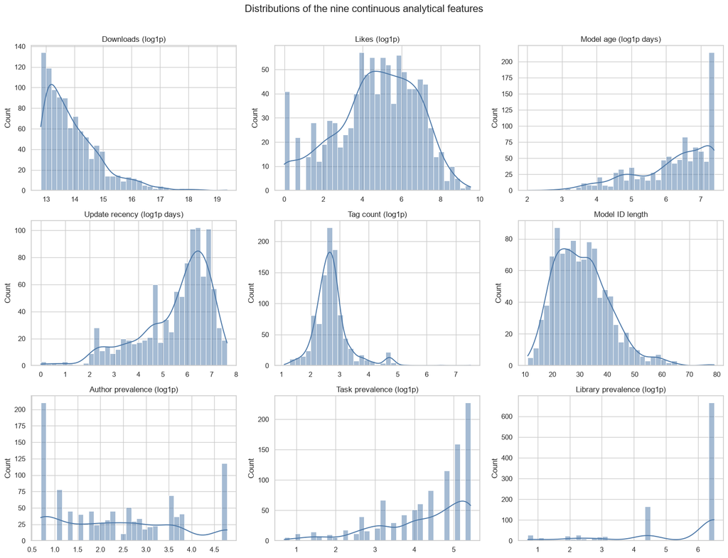

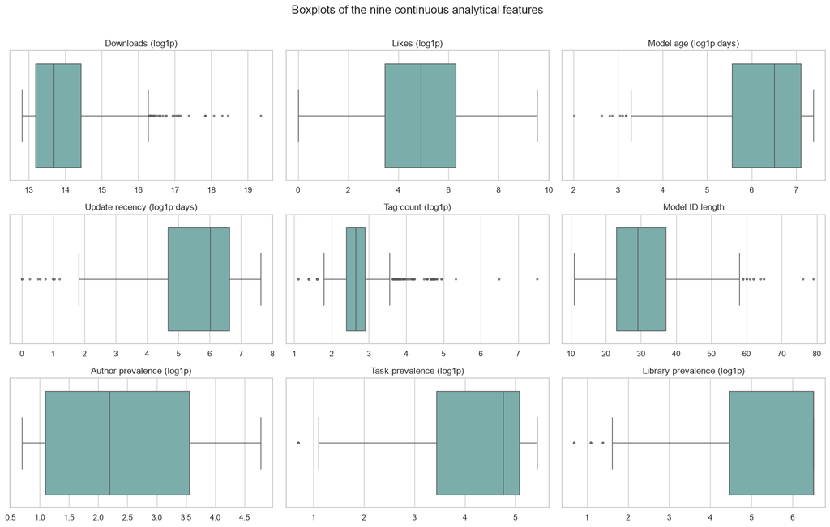

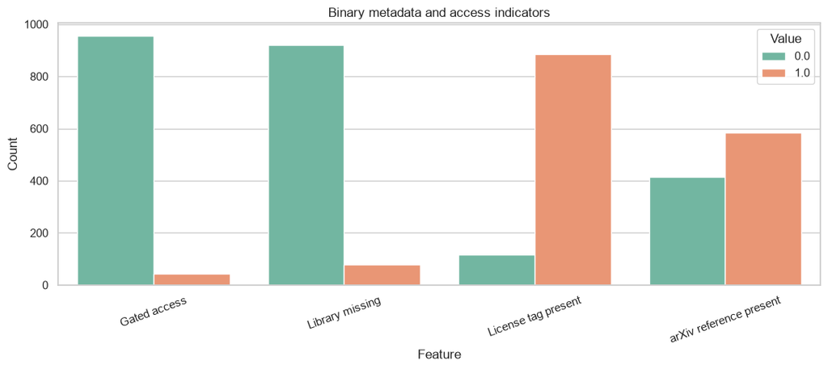

```python
distribution_stats = pd.DataFrame(
    {
        "mean": X_all.mean(),
        "std": X_all.std(ddof=1),
        "median": X_all.median(),
        "min": X_all.min(),
        "max": X_all.max(),
        "skewness": X_all.apply(lambda series: skew(series, bias=False)),
        "excess_kurtosis": X_all.apply(lambda series: kurtosis(series, fisher=True, bias=False)),
        "unique": X_all.nunique(),
    }
)
display(distribution_stats)

fig, axes = plt.subplots(3, 3, figsize=(16, 12))
for axis, feature in zip(axes.ravel(), continuous_features):
    sns.histplot(X[feature], bins=35, kde=True, ax=axis, color="#4C78A8")
    axis.set_title(feature_labels[feature])
    axis.set_xlabel("")
fig.suptitle("Distributions of the nine continuous analytical features", fontsize=16, y=1.01)
fig.tight_layout()
save_figure("01_feature_histograms.png")
plt.show()

fig, axes = plt.subplots(3, 3, figsize=(16, 10))
for axis, feature in zip(axes.ravel(), continuous_features):
    sns.boxplot(x=X[feature], ax=axis, color="#72B7B2", fliersize=2)
    axis.set_title(feature_labels[feature])
    axis.set_xlabel("")
fig.suptitle("Boxplots of the nine continuous analytical features", fontsize=16, y=1.01)
fig.tight_layout()
save_figure("02_feature_boxplots.png")
plt.show()

binary_long = X_all[binary_features].rename(columns=feature_labels).melt(var_name="Feature", value_name="Value")
binary_counts = binary_long.groupby(["Feature", "Value"]).size().rename("Count").reset_index()
fig, ax = plt.subplots(figsize=(11, 5))
sns.barplot(data=binary_counts, x="Feature", y="Count", hue="Value", ax=ax, palette="Set2")
ax.set_title("Binary metadata and access indicators")
ax.tick_params(axis="x", rotation=20)
fig.tight_layout()
save_figure("03_binary_feature_counts.png")
plt.show()
```

### 2.1 Distribution and data-quality findings

- The raw `license` field is completely missing. This is a collection limitation, not evidence that the repositories lack licenses: 88.5% of the latest rows contain a `license:` tag.
- `library_name` is missing in 13,300 raw rows and 7.9% of the latest snapshot. Missingness is retained explicitly because it may describe a distinct publication pattern.
- `private` is constant `False`, as expected for records returned by a public API, and adds no variance.
- Download counts, tag counts, and publisher/task/library prevalence have long tails. Log transformation reduces, but does not eliminate, their skewness.
- The binary `gated_flag` is rare: 44 of 1,000 models. If it were standardized and placed in the main Euclidean matrix, every gated row would receive a large coordinate. I therefore keep all four indicators for profiling and test their influence explicitly, rather than allowing access or documentation status to determine the primary clusters.
- The [official Hugging Face documentation](https://huggingface.co/docs/huggingface_hub/package_reference/hf_api) notes a lower bound around March 2, 2022 for stored creation dates. In this snapshot, 169 rows occur at the two boundary timestamps around that date. Apparent equal ages there are therefore a measurement artifact, not proof that all those repositories were created simultaneously.
- A high download count or an unusually rich tag list may be legitimate. Boxplot extremes are candidates for investigation, not automatic errors.

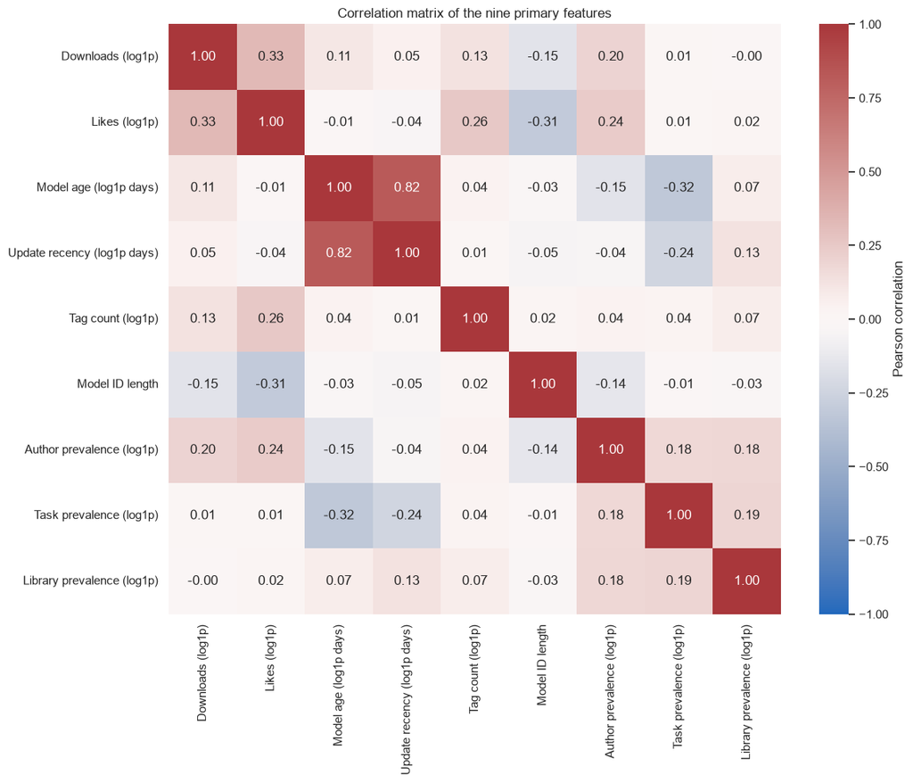

|  | feature_1 | feature_2 | correlation | absolute_correlation |
| --- | --- | --- | --- | --- |
| 15 | log_model_age_days | log_days_since_update | 0.822 | 0.822 |
| 0 | log_downloads | log_likes | 0.333 | 0.333 |
| 19 | log_model_age_days | log_pipeline_model_count | -0.323 | 0.323 |
| 11 | log_likes | model_id_length | -0.308 | 0.308 |
| 10 | log_likes | log_tag_count | 0.258 | 0.258 |
| 12 | log_likes | log_author_model_count | 0.240 | 0.240 |
| 24 | log_days_since_update | log_pipeline_model_count | -0.239 | 0.239 |
| 5 | log_downloads | log_author_model_count | 0.197 | 0.197 |
| 35 | log_pipeline_model_count | log_library_model_count | 0.193 | 0.193 |
| 34 | log_author_model_count | log_library_model_count | 0.180 | 0.180 |
| 33 | log_author_model_count | log_pipeline_model_count | 0.178 | 0.178 |
| 18 | log_model_age_days | log_author_model_count | -0.154 | 0.154 |

```python
corr = X.corr()
fig, ax = plt.subplots(figsize=(12, 10))
sns.heatmap(
    corr.rename(index=feature_labels, columns=feature_labels),
    cmap="vlag",
    center=0,
    vmin=-1,
    vmax=1,
    annot=True,
    fmt=".2f",
    ax=ax,
    cbar_kws={"label": "Pearson correlation"},
)
ax.set_title("Correlation matrix of the nine primary features")
fig.tight_layout()
save_figure("04_correlation_matrix.png")
plt.show()

correlation_pairs = pd.DataFrame(
    [
        {"feature_1": a, "feature_2": b, "correlation": corr.loc[a, b], "absolute_correlation": abs(corr.loc[a, b])}
        for a, b in combinations(feature_columns, 2)
    ]
).sort_values("absolute_correlation", ascending=False)
display(correlation_pairs.head(12))
```

### 2.2 Correlation, tails, and possible artifacts

The strongest relationship is between log model age and log days since update ($r=0.822$): older repositories tend also to have older last-update dates. Downloads and likes are positively related but far from interchangeable ($r=0.333$). This leaves substantial variation in machine use that is not mirrored by visible appreciation.

Strong age-recency correlation creates redundancy, so PCA should combine some of their shared variance. Most other absolute correlations are below 0.35. That weak correlation structure is an early warning that a very low-dimensional representation may lose considerable information.

Extreme values can arise from at least four sources: genuinely dominant infrastructure models, new models receiving sudden attention, extensive automatically attached tags, or incomplete/inconsistent metadata. There is no safe basis for deleting them before the anomaly analysis. The pipeline therefore uses monotonic log transforms, keeps all rows, and lets the three detectors disagree.

## 3. Dimensionality reduction with PCA

After standardization, PCA finds orthogonal directions $v_j$ that maximize projected variance. If $S$ is the sample covariance matrix, the first component solves

$$v_1 = \arg\max_{\|v\|=1} v^T S v,$$

and later components solve the same problem subject to orthogonality. The explained-variance ratio for component $j$ is $\lambda_j / \sum_k \lambda_k$.

PCA is global, linear, variance-based, and sensitive to the chosen features and scaling. It does not guarantee preservation of local neighborhoods, cluster density, or anomaly status.

|  | component | explained_variance_ratio | cumulative_explained_variance |
| --- | --- | --- | --- |
| 0 | 1 | 0.225 | 0.225 |
| 1 | 2 | 0.200 | 0.426 |
| 2 | 3 | 0.135 | 0.561 |
| 3 | 4 | 0.115 | 0.676 |
| 4 | 5 | 0.093 | 0.769 |
| 5 | 6 | 0.082 | 0.850 |
| 6 | 7 | 0.072 | 0.922 |
| 7 | 8 | 0.060 | 0.982 |
| 8 | 9 | 0.018 | 1.000 |

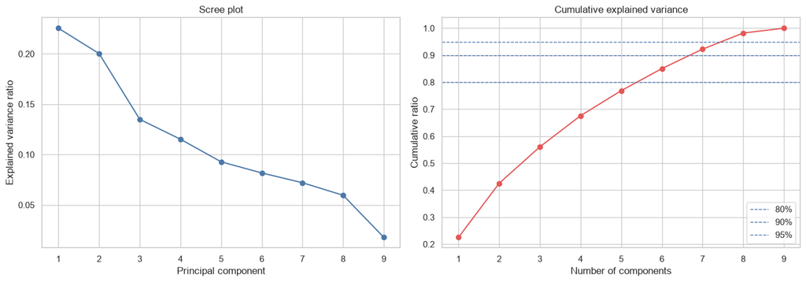

```
{0.8: 6, 0.9: 7, 0.95: 8}
```

```python
pca = PCA().fit(X_scaled)
pca_scores = pca.transform(X_scaled)
explained = pca.explained_variance_ratio_
cumulative = explained.cumsum()
pca_table = pd.DataFrame(
    {
        "component": np.arange(1, len(explained) + 1),
        "explained_variance_ratio": explained,
        "cumulative_explained_variance": cumulative,
    }
)
display(pca_table)

fig, axes = plt.subplots(1, 2, figsize=(14, 5))
axes[0].plot(pca_table["component"], explained, marker="o", color="#4C78A8")
axes[0].set_title("Scree plot")
axes[0].set_xlabel("Principal component")
axes[0].set_ylabel("Explained variance ratio")
axes[0].set_xticks(pca_table["component"])
axes[1].plot(pca_table["component"], cumulative, marker="o", color="#E45756")
for threshold in [.80, .90, .95]:
    axes[1].axhline(threshold, linestyle="--", linewidth=1, label=f"{threshold:.0%}")
axes[1].set_title("Cumulative explained variance")
axes[1].set_xlabel("Number of components")
axes[1].set_ylabel("Cumulative ratio")
axes[1].set_xticks(pca_table["component"])
axes[1].legend()
fig.tight_layout()
save_figure("05_pca_scree_and_cumulative.png")
plt.show()

components_needed = {
    threshold: int(np.searchsorted(cumulative, threshold) + 1)
    for threshold in [.80, .90, .95]
}
components_needed
```

|  | PC1 | PC2 | PC3 | PC4 |
| --- | --- | --- | --- | --- |
| log_model_age_days | 0.928 | 0.137 | 0.108 | 0.016 |
| log_days_since_update | 0.886 | 0.157 | 0.238 | -0.068 |
| log_pipeline_model_count | -0.542 | 0.126 | 0.493 | 0.012 |
| log_author_model_count | -0.280 | 0.542 | 0.287 | -0.229 |
| log_likes | -0.101 | 0.748 | -0.295 | 0.079 |
| log_downloads | 0.043 | 0.633 | -0.229 | 0.041 |
| log_library_model_count | 0.020 | 0.260 | 0.802 | 0.026 |
| log_tag_count | -0.007 | 0.395 | -0.027 | 0.818 |
| model_id_length | 0.000 | -0.516 | 0.196 | 0.551 |

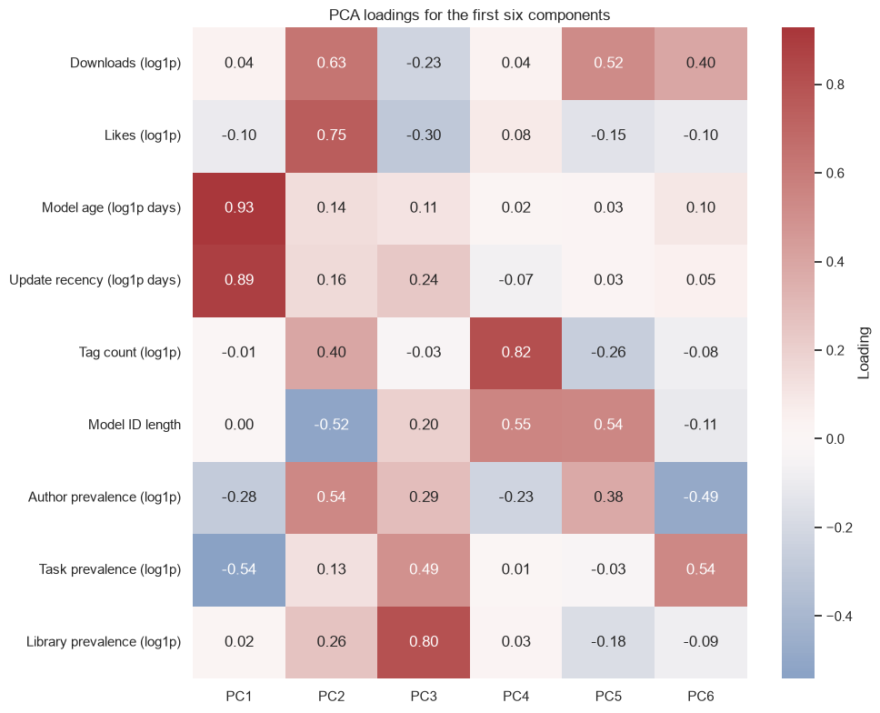

```python
loadings = pd.DataFrame(
    pca.components_.T * np.sqrt(pca.explained_variance_),
    index=feature_columns,
    columns=[f"PC{i + 1}" for i in range(len(feature_columns))],
)
display(loadings.iloc[:, :4].sort_values("PC1", key=abs, ascending=False))

fig, ax = plt.subplots(figsize=(10, 8))
sns.heatmap(
    loadings.iloc[:, :6].rename(index=feature_labels),
    cmap="vlag",
    center=0,
    annot=True,
    fmt=".2f",
    ax=ax,
    cbar_kws={"label": "Loading"},
)
ax.set_title("PCA loadings for the first six components")
fig.tight_layout()
save_figure("06_pca_loadings.png")
plt.show()
```

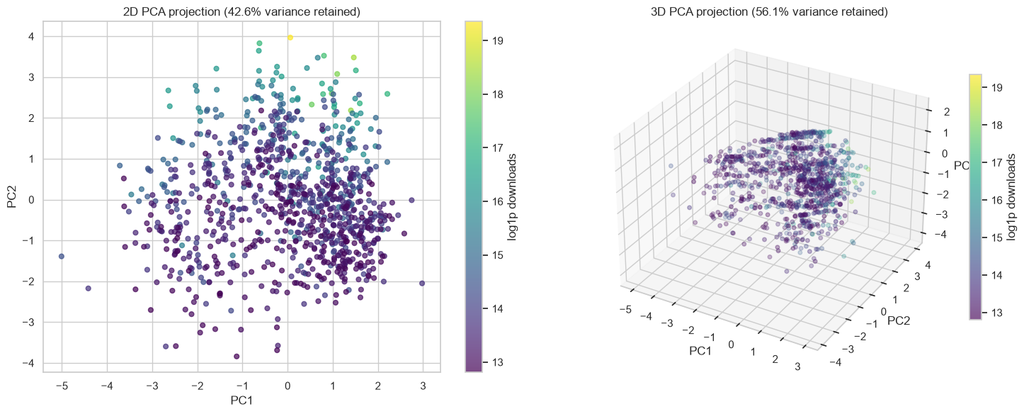

```python
projection = pd.DataFrame(pca_scores[:, :3], columns=["PC1", "PC2", "PC3"], index=models.index)
projection["log_downloads"] = models["log_downloads"]

fig = plt.figure(figsize=(15, 6))
ax2d = fig.add_subplot(1, 2, 1)
points = ax2d.scatter(
    projection["PC1"], projection["PC2"], c=projection["log_downloads"],
    cmap="viridis", s=24, alpha=.7
)
ax2d.set_title(f"2D PCA projection ({cumulative[1]:.1%} variance retained)")
ax2d.set_xlabel("PC1")
ax2d.set_ylabel("PC2")
fig.colorbar(points, ax=ax2d, label="log1p downloads")

ax3d = fig.add_subplot(1, 2, 2, projection="3d")
points3d = ax3d.scatter(
    projection["PC1"], projection["PC2"], projection["PC3"],
    c=projection["log_downloads"], cmap="viridis", s=16, alpha=.65
)
ax3d.set_title(f"3D PCA projection ({cumulative[2]:.1%} variance retained)")
ax3d.set_xlabel("PC1")
ax3d.set_ylabel("PC2")
ax3d.set_zlabel("PC3")
fig.colorbar(points3d, ax=ax3d, shrink=.7, label="log1p downloads")
fig.tight_layout()
save_figure("07_pca_2d_3d.png")
plt.show()
```

### 3.1 PCA interpretation

- The first two components retain 42.6% of standardized variance; three retain 56.1%. A 2D or 3D scatter plot still discards substantial information and is primarily a visualization aid.
- Six components are needed for at least 80%, seven for 90%, and eight for 95%. The nine continuous inputs can be reduced modestly, but not compressed to a small plane without substantial loss.
- PC1 is a lifecycle axis: model age and update recency load strongly in the positive direction, opposed mainly to task prevalence.
- PC2 combines popularity and ecosystem presence: likes, downloads, author prevalence, and tag richness are positive, while long identifiers are negative.
- PC3 is primarily ecosystem prevalence, with library and task prevalence carrying the largest loadings.
- PC4 is metadata/naming complexity: tag richness and identifier length dominate it.

The primary feature set contains one clear redundancy pair (age and update recency), but the cumulative-variance curve shows that most information is distributed across several directions. PCA improves visualization and removes linear correlation, yet retaining 90% of variance does not guarantee preservation of local density or anomaly status. It is computationally cheap here, but its components are less directly interpretable than the original nine variables. Conclusions therefore emphasize loadings, cumulative variance, and sensitivity results rather than treating a single scatter plot as the data itself.

## 4. Clustering analysis

Three algorithms test different definitions of a cluster.

### K-Means

K-Means minimizes within-cluster squared Euclidean distance:

$$\min_{C_1,\ldots,C_k} \sum_{j=1}^{k}\sum_{x_i\in C_j}\|x_i-\mu_j\|_2^2.$$

It is fast and easy to profile, but assumes centroid-like, roughly spherical groups with similar scale. It requires $k$ and is sensitive to outliers and initialization. I use 30 initializations and a fixed seed.

### DBSCAN

DBSCAN joins points that have at least `min_samples` observations within radius $\varepsilon$, expands density-connected regions, and labels unconnected points as noise. It can find non-spherical clusters and does not require $k$, but one global density threshold struggles when density varies or distance concentrates in high dimensions.

### Agglomerative clustering

Ward agglomeration starts with one cluster per observation and repeatedly merges the pair that causes the smallest increase in within-cluster sum of squares. It exposes hierarchy and is deterministic for fixed data, but early merges cannot be undone, the cut level must be chosen, and computation/memory scale poorly for very large $n$.

|  | method | k | inertia | clusters | noise_fraction | silhouette | calinski_harabasz | davies_bouldin |
| --- | --- | --- | --- | --- | --- | --- | --- | --- |
| 0 | K-Means | 2 | 7,504.095 | 2 | 0.000 | 0.173 | 198.961 | 2.114 |
| 1 | Agglomerative | 2 | NaN | 2 | 0.000 | 0.180 | 167.893 | 1.872 |
| 2 | K-Means | 3 | 6,490.744 | 3 | 0.000 | 0.175 | 192.715 | 1.815 |
| 3 | Agglomerative | 3 | NaN | 3 | 0.000 | 0.159 | 163.985 | 2.036 |
| 4 | K-Means | 4 | 5,879.830 | 4 | 0.000 | 0.176 | 176.178 | 1.759 |
| 5 | Agglomerative | 4 | NaN | 4 | 0.000 | 0.154 | 147.006 | 1.764 |
| 6 | K-Means | 5 | 5,404.910 | 5 | 0.000 | 0.182 | 165.457 | 1.664 |
| 7 | Agglomerative | 5 | NaN | 5 | 0.000 | 0.146 | 139.671 | 1.790 |
| 8 | K-Means | 6 | 5,067.284 | 6 | 0.000 | 0.168 | 154.289 | 1.661 |
| 9 | Agglomerative | 6 | NaN | 6 | 0.000 | 0.143 | 130.899 | 1.716 |
| 10 | K-Means | 7 | 4,793.811 | 7 | 0.000 | 0.171 | 145.213 | 1.589 |
| 11 | Agglomerative | 7 | NaN | 7 | 0.000 | 0.152 | 123.947 | 1.590 |
| 12 | K-Means | 8 | 4,536.640 | 8 | 0.000 | 0.170 | 139.425 | 1.642 |
| 13 | Agglomerative | 8 | NaN | 8 | 0.000 | 0.128 | 116.394 | 1.685 |
| 14 | K-Means | 9 | 4,338.682 | 9 | 0.000 | 0.170 | 133.087 | 1.588 |
| 15 | Agglomerative | 9 | NaN | 9 | 0.000 | 0.133 | 111.238 | 1.591 |
| 16 | K-Means | 10 | 4,178.801 | 10 | 0.000 | 0.153 | 126.910 | 1.572 |
| 17 | Agglomerative | 10 | NaN | 10 | 0.000 | 0.128 | 107.837 | 1.725 |

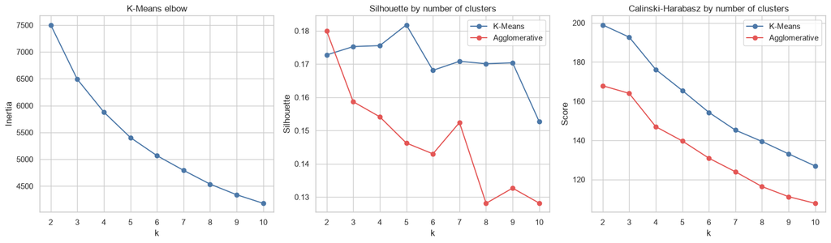

```python
def clustering_metrics(values: np.ndarray, labels: np.ndarray) -> dict[str, float]:
    labels = np.asarray(labels)
    keep = labels != -1
    evaluated_labels = labels[keep]
    n_clusters = len(set(evaluated_labels))
    metrics = {
        "clusters": n_clusters,
        "noise_fraction": float((~keep).mean()),
        "silhouette": np.nan,
        "calinski_harabasz": np.nan,
        "davies_bouldin": np.nan,
    }
    if n_clusters >= 2 and keep.sum() > n_clusters:
        metrics.update(
            {
                "silhouette": silhouette_score(values[keep], evaluated_labels),
                "calinski_harabasz": calinski_harabasz_score(values[keep], evaluated_labels),
                "davies_bouldin": davies_bouldin_score(values[keep], evaluated_labels),
            }
        )
    return metrics


parameter_rows = []
for k in range(2, 11):
    kmeans = KMeans(n_clusters=k, n_init=30, random_state=SEED).fit(X_scaled)
    parameter_rows.append(
        {"method": "K-Means", "k": k, "inertia": kmeans.inertia_, **clustering_metrics(X_scaled, kmeans.labels_)}
    )
    ward = AgglomerativeClustering(n_clusters=k, linkage="ward").fit(X_scaled)
    parameter_rows.append(
        {"method": "Agglomerative", "k": k, "inertia": np.nan, **clustering_metrics(X_scaled, ward.labels_)}
    )
parameter_sweep = pd.DataFrame(parameter_rows)
display(parameter_sweep)

fig, axes = plt.subplots(1, 3, figsize=(16, 4.8))
kmeans_sweep = parameter_sweep.query("method == 'K-Means'")
axes[0].plot(kmeans_sweep["k"], kmeans_sweep["inertia"], marker="o", color="#4C78A8")
axes[0].set_title("K-Means elbow")
axes[0].set_ylabel("Inertia")
for method, color in [("K-Means", "#4C78A8"), ("Agglomerative", "#E45756")]:
    subset = parameter_sweep.query("method == @method")
    axes[1].plot(subset["k"], subset["silhouette"], marker="o", label=method, color=color)
    axes[2].plot(subset["k"], subset["calinski_harabasz"], marker="o", label=method, color=color)
axes[1].set_title("Silhouette by number of clusters")
axes[1].set_ylabel("Silhouette")
axes[2].set_title("Calinski-Harabasz by number of clusters")
axes[2].set_ylabel("Score")
for axis in axes:
    axis.set_xlabel("k")
axes[1].legend()
axes[2].legend()
fig.tight_layout()
save_figure("08_clustering_parameter_selection.png")
plt.show()
```

|  | neighbor_quantile | epsilon | clusters | noise_fraction | silhouette | calinski_harabasz | davies_bouldin |
| --- | --- | --- | --- | --- | --- | --- | --- |
| 0 | 0.500 | 1.603 | 1 | 0.320 | NaN | NaN | NaN |
| 1 | 0.600 | 1.751 | 1 | 0.230 | NaN | NaN | NaN |
| 2 | 0.700 | 1.901 | 2 | 0.132 | 0.197 | 16.084 | 1.061 |
| 3 | 0.750 | 1.998 | 2 | 0.093 | 0.222 | 47.199 | 1.246 |
| 4 | 0.800 | 2.113 | 1 | 0.063 | NaN | NaN | NaN |
| 5 | 0.850 | 2.266 | 1 | 0.045 | NaN | NaN | NaN |
| 6 | 0.900 | 2.430 | 1 | 0.026 | NaN | NaN | NaN |
| 7 | 0.950 | 2.616 | 1 | 0.009 | NaN | NaN | NaN |

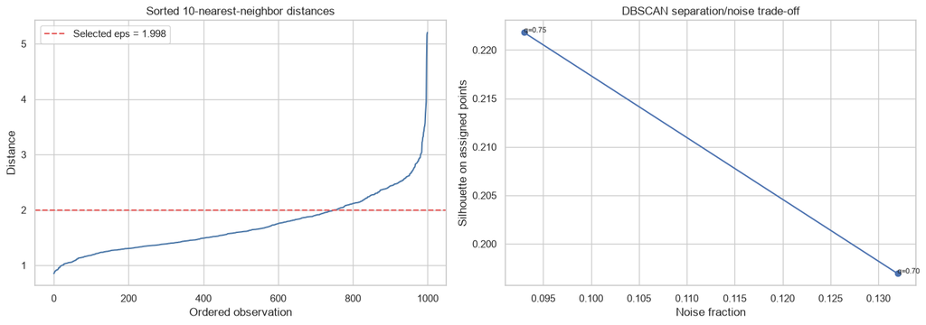

```python
DBSCAN_MIN_SAMPLES = 10
neighbor_distances = NearestNeighbors(n_neighbors=DBSCAN_MIN_SAMPLES).fit(X_scaled).kneighbors(X_scaled)[0][:, -1]
DBSCAN_QUANTILE = .75
DBSCAN_EPS = float(np.quantile(neighbor_distances, DBSCAN_QUANTILE))

dbscan_rows = []
for quantile in [.50, .60, .70, .75, .80, .85, .90, .95]:
    epsilon = float(np.quantile(neighbor_distances, quantile))
    labels = DBSCAN(eps=epsilon, min_samples=DBSCAN_MIN_SAMPLES).fit_predict(X_scaled)
    dbscan_rows.append(
        {"neighbor_quantile": quantile, "epsilon": epsilon, **clustering_metrics(X_scaled, labels)}
    )
dbscan_sweep = pd.DataFrame(dbscan_rows)
display(dbscan_sweep)

fig, axes = plt.subplots(1, 2, figsize=(14, 5))
axes[0].plot(np.sort(neighbor_distances), color="#4C78A8")
axes[0].axhline(DBSCAN_EPS, linestyle="--", color="#E45756", label=f"Selected eps = {DBSCAN_EPS:.3f}")
axes[0].set_title(f"Sorted {DBSCAN_MIN_SAMPLES}-nearest-neighbor distances")
axes[0].set_xlabel("Ordered observation")
axes[0].set_ylabel("Distance")
axes[0].legend()
axes[1].plot(dbscan_sweep["noise_fraction"], dbscan_sweep["silhouette"], marker="o")
for _, row in dbscan_sweep.iterrows():
    axes[1].annotate(f"q={row['neighbor_quantile']:.2f}", (row["noise_fraction"], row["silhouette"]), fontsize=8)
axes[1].set_title("DBSCAN separation/noise trade-off")
axes[1].set_xlabel("Noise fraction")
axes[1].set_ylabel("Silhouette on assigned points")
fig.tight_layout()
save_figure("09_dbscan_parameter_selection.png")
plt.show()
```

```python
KMEANS_K = 5
AGGLOMERATIVE_K = 2

cluster_labels = {
    "K-Means": KMeans(n_clusters=KMEANS_K, n_init=30, random_state=SEED).fit_predict(X_scaled),
    "DBSCAN": DBSCAN(eps=DBSCAN_EPS, min_samples=DBSCAN_MIN_SAMPLES).fit_predict(X_scaled),
    "Agglomerative": AgglomerativeClustering(n_clusters=AGGLOMERATIVE_K, linkage="ward").fit_predict(X_scaled),
}


def within_global_variance_ratio(values: np.ndarray, labels: np.ndarray) -> float:
    labels = np.asarray(labels)
    keep = labels != -1
    retained_values = values[keep]
    retained_labels = labels[keep]
    global_variance = retained_values.var(axis=0, ddof=0)
    weighted_within = np.zeros(retained_values.shape[1])
    for label in np.unique(retained_labels):
        group = retained_values[retained_labels == label]
        weighted_within += len(group) * group.var(axis=0, ddof=0)
    weighted_within /= len(retained_values)
    ratios = np.divide(
        weighted_within,
        global_variance,
        out=np.zeros_like(weighted_within),
        where=global_variance > 0,
    )
    return float(ratios.mean())


rng = np.random.default_rng(SEED)
cluster_evaluation = []
for method, labels in cluster_labels.items():
    stability = []
    for trial in range(10):
        perturbed = X_scaled + rng.normal(0, .03, X_scaled.shape)
        if method == "K-Means":
            trial_labels = KMeans(n_clusters=KMEANS_K, n_init=20, random_state=SEED + trial).fit_predict(perturbed)
        elif method == "DBSCAN":
            trial_labels = DBSCAN(eps=DBSCAN_EPS, min_samples=DBSCAN_MIN_SAMPLES).fit_predict(perturbed)
        else:
            trial_labels = AgglomerativeClustering(n_clusters=AGGLOMERATIVE_K, linkage="ward").fit_predict(perturbed)
        stability.append(adjusted_rand_score(labels, trial_labels))
    cluster_evaluation.append(
        {
            "method": method,
            **clustering_metrics(X_scaled, labels),
            "within/global variance": within_global_variance_ratio(X_scaled, labels),
            "mean jitter ARI": np.mean(stability),
            "minimum jitter ARI": np.min(stability),
        }
    )
cluster_evaluation = pd.DataFrame(cluster_evaluation).set_index("method")
display(cluster_evaluation)

cluster_assignment = models[["id", "author", "pipeline_tag", "library_clean"]].copy()
for method, labels in cluster_labels.items():
    cluster_assignment[method] = labels
cluster_assignment.to_csv(ROOT / "reports" / "clustering_results.csv", index=False, lineterminator="\n")
```

| method | clusters | noise_fraction | silhouette | calinski_harabasz | davies_bouldin | within/global variance | mean jitter ARI | minimum jitter ARI |
| --- | --- | --- | --- | --- | --- | --- | --- | --- |
| K-Means | 5 | 0.000 | 0.182 | 165.457 | 1.664 | 0.601 | 0.966 | 0.957 |
| DBSCAN | 2 | 0.093 | 0.222 | 47.199 | 1.246 | 0.945 | 0.925 | 0.791 |
| Agglomerative | 2 | 0.000 | 0.180 | 167.893 | 1.872 | 0.856 | 0.520 | 0.306 |

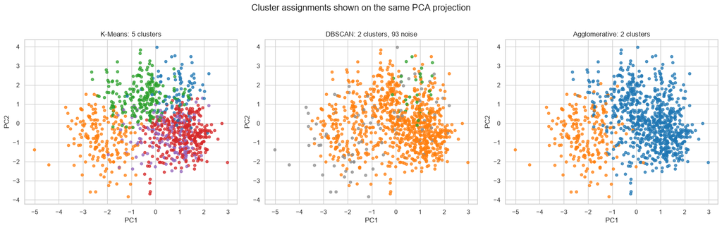

```python
fig, axes = plt.subplots(1, 3, figsize=(18, 5.5))
for axis, (method, labels) in zip(axes, cluster_labels.items()):
    unique_labels = sorted(np.unique(labels))
    palette = sns.color_palette("tab10", n_colors=len(unique_labels))
    colors = [palette[unique_labels.index(label)] if label != -1 else (.55, .55, .55) for label in labels]
    axis.scatter(projection["PC1"], projection["PC2"], c=colors, s=22, alpha=.75)
    axis.set_title(f"{method}: {len(set(labels) - {-1})} clusters" + (f", {(labels == -1).sum()} noise" if -1 in labels else ""))
    axis.set_xlabel("PC1")
    axis.set_ylabel("PC2")
fig.suptitle("Cluster assignments shown on the same PCA projection", fontsize=16, y=1.02)
fig.tight_layout()
save_figure("10_cluster_pca_comparison.png")
plt.show()
```

K-Means median cluster profiles

| cluster | n | downloads | likes | model_age_days | days_since_update | tag_count | author_model_count | pipeline_model_count | library_model_count | gated_flag |
| --- | --- | --- | --- | --- | --- | --- | --- | --- | --- | --- |
| 0 | 101 | 4,150,293.000 | 382.000 | 1,167.692 | 756.382 | 26.000 | 8.000 | 51.000 | 665.000 | 0.000 |
| 1 | 187 | 697,666.000 | 60.000 | 98.006 | 28.502 | 13.000 | 9.000 | 159.000 | 665.000 | 0.000 |
| 2 | 220 | 1,284,094.500 | 615.000 | 457.786 | 368.841 | 14.000 | 118.000 | 227.000 | 665.000 | 0.000 |
| 3 | 343 | 687,370.000 | 55.000 | 1,167.718 | 719.853 | 12.000 | 2.000 | 61.000 | 665.000 | 0.000 |
| 4 | 149 | 769,593.000 | 110.000 | 699.138 | 347.791 | 10.000 | 5.000 | 23.000 | 10.000 | 0.000 |

DBSCAN median cluster profiles

| cluster | n | downloads | likes | model_age_days | days_since_update | tag_count | author_model_count | pipeline_model_count | library_model_count | gated_flag |
| --- | --- | --- | --- | --- | --- | --- | --- | --- | --- | --- |
| -1 | 93 | 1,019,206.000 | 380.000 | 207.567 | 42.212 | 16.000 | 4.000 | 83.000 | 21.000 | 0.000 |
| 0 | 879 | 843,617.000 | 112.000 | 680.419 | 444.946 | 13.000 | 9.000 | 115.000 | 665.000 | 0.000 |
| 1 | 28 | 1,991,294.500 | 356.500 | 979.595 | 847.985 | 113.000 | 7.000 | 61.000 | 665.000 | 0.000 |

Agglomerative median cluster profiles

| cluster | n | downloads | likes | model_age_days | days_since_update | tag_count | author_model_count | pipeline_model_count | library_model_count | gated_flag |
| --- | --- | --- | --- | --- | --- | --- | --- | --- | --- | --- |
| 0 | 787 | 908,203.000 | 141.000 | 839.536 | 540.974 | 13.000 | 8.000 | 83.000 | 665.000 | 0.000 |
| 1 | 213 | 742,956.000 | 105.000 | 104.020 | 33.279 | 13.000 | 9.000 | 159.000 | 665.000 | 0.000 |

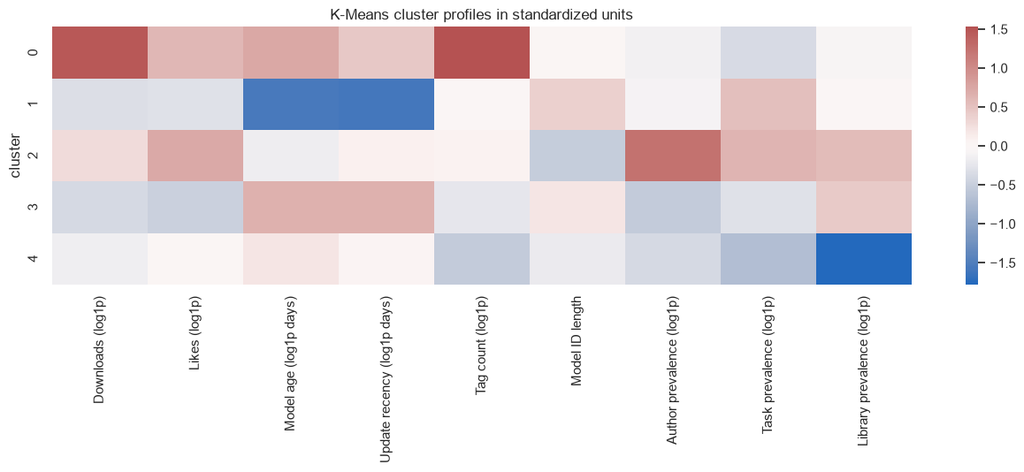

```python
profile_columns = [
    "downloads", "likes", "model_age_days", "days_since_update", "tag_count",
    "author_model_count", "pipeline_model_count", "library_model_count", "gated_flag",
]

for method, labels in cluster_labels.items():
    profile = models[profile_columns].assign(cluster=labels).groupby("cluster").median()
    profile.insert(0, "n", pd.Series(labels).value_counts().sort_index())
    display(Markdown(f"### {method} median cluster profiles"))
    display(profile)

kmeans_profile_z = pd.DataFrame(X_scaled, columns=feature_columns).assign(cluster=cluster_labels["K-Means"]).groupby("cluster").mean()
fig, ax = plt.subplots(figsize=(13, 5.5))
sns.heatmap(kmeans_profile_z.rename(columns=feature_labels), cmap="vlag", center=0, ax=ax)
ax.set_title("K-Means cluster profiles in standardized units")
ax.set_xlabel("")
fig.tight_layout()
save_figure("11_kmeans_cluster_profiles.png")
plt.show()
```

### 4.1 Parameter choice and evaluation

For K-Means, $k=5$ maximizes silhouette in the tested range (0.182) and lies after the main inertia decline. Ward clustering is cut at $k=2$, where its tested silhouette is maximal (0.180); deeper cuts are reported in the sweep but are not promoted merely because they create more profiles. For DBSCAN, `min_samples=10` and the 75th percentile of 10-neighbor distances produce two density-connected regions and 9.3% noise. This setting has the strongest assigned-point silhouette among the valid grid candidates (0.222), while keeping most observations. Choosing DBSCAN only by silhouette without the noise fraction could reward a setting that discards hard observations.

The average within/global variance ratio is appropriate as a compactness diagnostic for K-Means because it matches the geometry the method optimizes. It is not sufficient for model selection: it falls as more clusters are added, ignores between-cluster separation, favors spherical groups, and is especially optimistic for DBSCAN when noise is excluded. Silhouette, Calinski-Harabasz, Davies-Bouldin, noise coverage, stability, and interpretability are therefore reported together.

### 4.2 Real-world interpretation

**K-Means:** cluster 0 contains older, exceptionally downloaded and richly tagged models. Cluster 1 is young, recently updated, and lower-engagement. Cluster 2 has the highest median likes and is associated with publishers that have many trending entries. Cluster 3 is the largest, older, stale, modest-engagement group. Cluster 4 is an intermediate-age, moderate-engagement profile. These are descriptive personas, not natural species, and binary access status is not used to define them.

**DBSCAN:** cluster 0 is the large dense core (879 models). Cluster 1 is a small, unusually metadata-rich region with a median of 113 tags. The 93 noise points occupy sparse combinations of the nine continuous features; `noise` means low density under this parameterization, not incorrect data.

**Agglomerative:** the two-branch cut separates a broad, older group from a smaller, much newer and more recently updated group. Its hierarchy exposes a lifecycle split, but the perturbation test warns that exact membership is fragile.

Algorithms disagree because they optimize different objects. K-Means partitions every point around centroids, Ward greedily builds a variance hierarchy, and DBSCAN requires density connectivity and may refuse to assign a point. Unequal densities, elongated age/recency structure, and weak separation violate the simplest assumptions. The later feature-set sensitivity test also confirms that adding rare binaries would substantially change these partitions. Cluster profiles are useful summaries, but it would be misleading to claim a single true segmentation.

## 4.3 Clustering the feature space

To cluster features rather than models, I transpose the standardized primary matrix from $1000\times9$ to $9\times1000$. Euclidean distance between two standardized feature vectors is a monotonic function of their correlation, so nearby feature rows tend to move together across models. Ward clustering is applied to the transpose, and the number of feature groups is selected from $k=2,\ldots,6$ by silhouette.

|  | k | silhouette |
| --- | --- | --- |
| 0 | 2 | 0.166 |
| 1 | 3 | 0.169 |
| 2 | 4 | 0.172 |
| 3 | 5 | 0.155 |
| 4 | 6 | 0.145 |

|  | feature | description | group |
| --- | --- | --- | --- |
| 6 | log_author_model_count | Author prevalence (log1p) | 0 |
| 0 | log_downloads | Downloads (log1p) | 0 |
| 1 | log_likes | Likes (log1p) | 0 |
| 4 | log_tag_count | Tag count (log1p) | 0 |
| 3 | log_days_since_update | Update recency (log1p days) | 1 |
| 2 | log_model_age_days | Model age (log1p days) | 1 |
| 8 | log_library_model_count | Library prevalence (log1p) | 2 |
| 7 | log_pipeline_model_count | Task prevalence (log1p) | 2 |
| 5 | model_id_length | Model ID length | 3 |

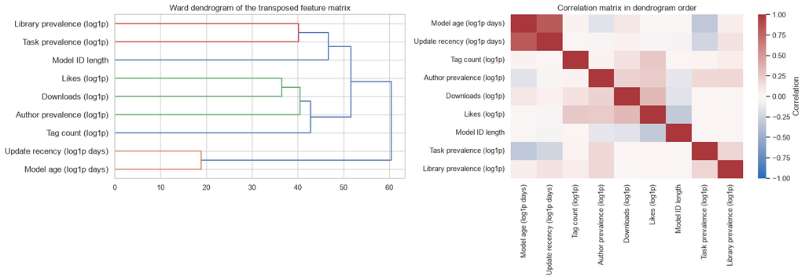

```python
feature_cluster_rows = []
for k in range(2, 7):
    labels = AgglomerativeClustering(n_clusters=k, linkage="ward").fit_predict(X_scaled.T)
    feature_cluster_rows.append(
        {"k": k, "silhouette": silhouette_score(X_scaled.T, labels), "labels": labels}
    )
feature_cluster_sweep = pd.DataFrame(
    [{"k": row["k"], "silhouette": row["silhouette"]} for row in feature_cluster_rows]
)
display(feature_cluster_sweep)
best_feature_result = max(feature_cluster_rows, key=lambda row: row["silhouette"])
feature_group_table = pd.DataFrame(
    {
        "feature": feature_columns,
        "description": [feature_labels[name] for name in feature_columns],
        "group": best_feature_result["labels"],
    }
).sort_values(["group", "feature"])
display(feature_group_table)

feature_linkage = linkage(X_scaled.T, method="ward")
fig, axes = plt.subplots(1, 2, figsize=(17, 6))
dendro = dendrogram(
    feature_linkage,
    labels=[feature_labels[name] for name in feature_columns],
    orientation="right",
    ax=axes[0],
)
axes[0].set_title("Ward dendrogram of the transposed feature matrix")
ordered_features = [feature_columns[index] for index in dendro["leaves"]]
sns.heatmap(
    corr.loc[ordered_features, ordered_features].rename(index=feature_labels, columns=feature_labels),
    cmap="vlag", center=0, vmin=-1, vmax=1, ax=axes[1], cbar_kws={"label": "Correlation"}
)
axes[1].set_title("Correlation matrix in dendrogram order")
fig.tight_layout()
save_figure("12_feature_clustering.png")
plt.show()
```

### 4.4 What feature clustering adds

The best tested cut is four groups, but its silhouette is only 0.172, so the hierarchy is suggestive rather than definitive.

1. **Popularity and visible footprint:** downloads, likes, tag richness, and author prevalence move together across the snapshot.
2. **Lifecycle:** model age and time since update form the clearest pair, matching their $r=0.822$ correlation and confirming redundancy already visible in PCA.
3. **Ecosystem prevalence:** task and library prevalence form a pair that measures how common the model's technical context is.
4. **Identifier structure:** model ID length remains a singleton at this cut, showing that it does not share a sufficiently similar pattern with the other continuous features.

Clustering samples showed model personas; clustering features exposes dependencies and possible feature hierarchies. This is especially useful in sensor networks, finance, genomics, text representations, and any domain with many correlated measurements, where groups can guide redundancy reduction or domain-specific composite features. Here it suggests that age/recency could be compressed, while most other features should not be removed solely from pairwise correlation.

## 5. Multi-dimensional anomaly detection

An anomaly means an observation that is unusual under a specified representation and method. No ground-truth anomaly label exists, so the goal is comparison and interpretation, not accuracy estimation.

### 5.1 Classical Z-score

For continuous feature $j$,

$$z_{ij}=\frac{x_{ij}-\bar{x}_j}{s_j}.$$

A row is classically flagged if any continuous feature has $|z|>3$. This is feature-wise: one extreme coordinate is sufficient. A global alternative such as $\sqrt{\sum_j z_{ij}^2}$ can detect several moderate deviations, but it double-counts correlated variables such as age and update recency; a chi-square interpretation would also be invalid without multivariate Gaussianity and independence. I therefore keep the transparent feature-wise rule as the primary Z-score result. For a fair overlap comparison with methods using 5% contamination, I also rank rows by $\max_j|z_{ij}|$ and take the top 50. Binary indicators are excluded from the classical Z-score because a Gaussian tail interpretation is inappropriate for a rare Bernoulli variable.

The method is transparent and affine-scale invariant, but it assumes mean/standard deviation are meaningful. Skew, heavy tails, correlation, multiple comparisons across dimensions, and anomalies that are unusual only in combinations can all cause failure. As dimension grows, the chance that at least one ordinary coordinate crosses a fixed threshold also grows.

```
Classical |z| > 3 flags: 70
Equal-budget top 5% flags: 50
```

|  | id | max_abs_z | most_extreme_feature | classical_flag | equal_budget_flag |
| --- | --- | --- | --- | --- | --- |
| 683 | jhu-clsp/mmBERT-base | 7.795 | log_tag_count | True | True |
| 508 | k2-fsa/OmniVoice | 6.133 | log_tag_count | True | True |
| 0 | sentence-transformers/all-MiniLM-L6-v2 | 5.583 | log_downloads | True | True |
| 450 | DavidAU/Qwen3.6-27B-Fable-Fusion-711-Uncensore... | 4.788 | model_id_length | True | True |
| 1 | google-bert/bert-base-uncased | 4.658 | log_downloads | True | True |
| 924 | nvidia/Qwen3-VL-235B-A22B-Instruct-NVFP4-MLPer... | 4.491 | model_id_length | True | True |
| 2 | cross-encoder/ms-marco-MiniLM-L6-v2 | 4.490 | log_downloads | True | True |
| 3 | BAAI/bge-small-en-v1.5 | 4.255 | log_downloads | True | True |
| 233 | facebook/nllb-200-distilled-600M | 4.241 | log_tag_count | True | True |
| 4 | sentence-transformers/paraphrase-multilingual-... | 4.017 | log_downloads | True | True |
| 5 | google/electra-base-discriminator | 4.015 | log_downloads | True | True |
| 256 | farbodtavakkoli/OTel-2.0-LLM-31B-IT | 3.847 | log_model_age_days | True | True |
| 350 | RedHatAI/gemma-4-31B-it-NVFP4 | 3.819 | log_days_since_update | True | True |
| 78 | RedHatAI/gemma-4-31B-it-FP8-block | 3.819 | log_days_since_update | True | True |
| 973 | DeepBeepMeep/Wan2.1 | 3.647 | log_days_since_update | True | True |

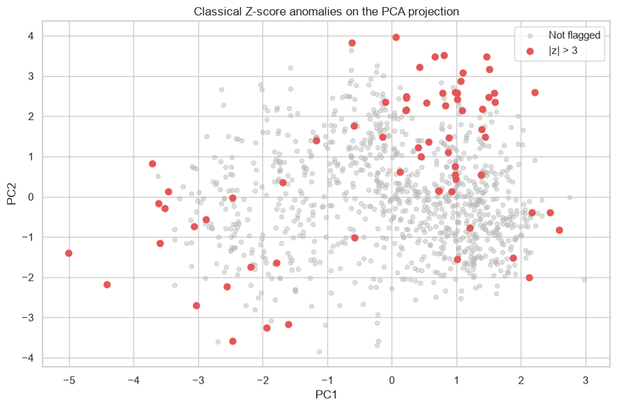

```python
anomaly_budget = int(round(.05 * len(models)))


def top_n_flags(scores: np.ndarray, n: int = anomaly_budget) -> np.ndarray:
    scores = np.asarray(scores)
    flags = np.zeros(len(scores), dtype=bool)
    flags[np.argpartition(scores, -n)[-n:]] = True
    return flags


runtime_seconds = {}
start = perf_counter()
z_matrix = np.abs(StandardScaler().fit_transform(models[continuous_features]))
z_scores = z_matrix.max(axis=1)
z_classical_flags = z_scores > 3
z_equal_budget_flags = top_n_flags(z_scores)
runtime_seconds["Z-score"] = perf_counter() - start

z_contributor = np.asarray(continuous_features)[z_matrix.argmax(axis=1)]
z_results = pd.DataFrame(
    {
        "id": models["id"].to_numpy(),
        "max_abs_z": z_scores,
        "most_extreme_feature": z_contributor,
        "classical_flag": z_classical_flags,
        "equal_budget_flag": z_equal_budget_flags,
    }
).sort_values("max_abs_z", ascending=False)
print(f"Classical |z| > 3 flags: {z_classical_flags.sum()}")
print(f"Equal-budget top 5% flags: {z_equal_budget_flags.sum()}")
display(z_results.head(15))

fig, ax = plt.subplots(figsize=(9, 6))
ax.scatter(projection["PC1"], projection["PC2"], c="#B8B8B8", s=20, alpha=.45, label="Not flagged")
ax.scatter(projection.loc[z_classical_flags, "PC1"], projection.loc[z_classical_flags, "PC2"], c="#E45756", s=42, label="|z| > 3")
ax.set_title("Classical Z-score anomalies on the PCA projection")
ax.set_xlabel("PC1")
ax.set_ylabel("PC2")
ax.legend()
fig.tight_layout()
save_figure("13_zscore_anomalies.png")
plt.show()
```

### 5.2 Isolation Forest

Isolation Forest repeatedly selects a random feature and a random split between that feature's observed minimum and maximum. Unusual observations tend to be isolated after fewer splits. If $h(x)$ is path length and $c(\psi)$ is the expected unsuccessful search length for subsample size $\psi$, the original anomaly score is

$$s(x,\psi)=2^{-E[h(x)]/c(\psi)}.$$

High original scores mean short paths and greater abnormality; values near 0.5 are less decisive. Scikit-learn exposes lower `score_samples` values for more abnormal rows, so I negate them: larger reported values are more anomalous and smaller values are more typical.

`contamination=0.05` does not discover that 5% of reality is abnormal; it sets the decision threshold so exactly 5% of this sample is flagged. The ensemble handles nonlinear interactions and high-dimensional data better than a univariate rule, but results depend on the included features, randomness, contamination, and whether anomalies can be isolated by axis-aligned cuts.

|  | contamination | flagged | Jaccard vs 5% | anomaly_score_threshold |
| --- | --- | --- | --- | --- |
| 0 | 0.010 | 10 | 0.200 | 0.580 |
| 1 | 0.025 | 25 | 0.500 | 0.566 |
| 2 | 0.050 | 50 | 1.000 | 0.550 |
| 3 | 0.075 | 75 | 0.667 | 0.535 |
| 4 | 0.100 | 100 | 0.500 | 0.525 |

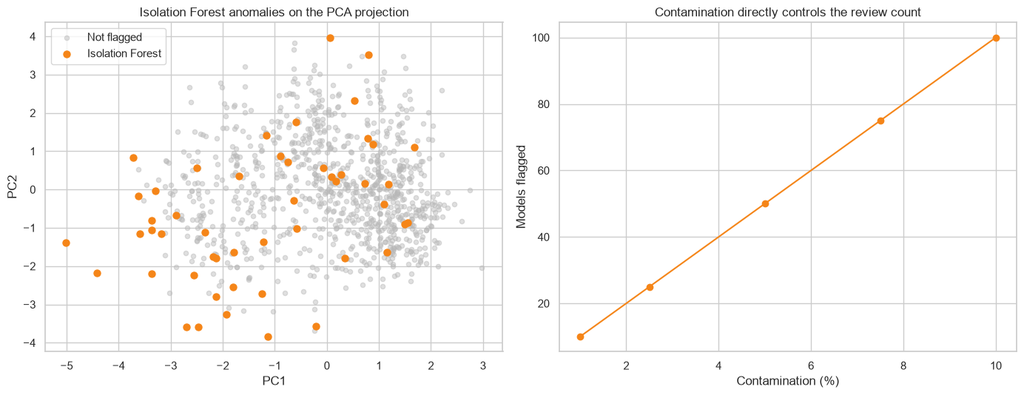

```python
start = perf_counter()
isolation_forest = IsolationForest(
    n_estimators=400,
    contamination=.05,
    random_state=SEED,
    n_jobs=-1,
)
isolation_labels = isolation_forest.fit_predict(X_scaled)
isolation_scores = -isolation_forest.score_samples(X_scaled)
isolation_flags = isolation_labels == -1
runtime_seconds["Isolation Forest"] = perf_counter() - start

contamination_rows = []
for contamination in [.01, .025, .05, .075, .10]:
    detector = IsolationForest(
        n_estimators=400,
        contamination=contamination,
        random_state=SEED,
        n_jobs=-1,
    ).fit(X_scaled)
    flags = detector.predict(X_scaled) == -1
    union = (flags | isolation_flags).sum()
    contamination_rows.append(
        {
            "contamination": contamination,
            "flagged": int(flags.sum()),
            "Jaccard vs 5%": (flags & isolation_flags).sum() / union,
            "anomaly_score_threshold": -float(detector.offset_),
        }
    )
if_contamination_sensitivity = pd.DataFrame(contamination_rows)
if_contamination_sensitivity.to_csv(ROOT / "reports" / "if_contamination_sensitivity.csv", index=False, lineterminator="\n")
display(if_contamination_sensitivity)

fig, axes = plt.subplots(1, 2, figsize=(14, 5.5))
axes[0].scatter(projection["PC1"], projection["PC2"], c="#B8B8B8", s=20, alpha=.45, label="Not flagged")
axes[0].scatter(projection.loc[isolation_flags, "PC1"], projection.loc[isolation_flags, "PC2"], c="#F58518", s=42, label="Isolation Forest")
axes[0].set_title("Isolation Forest anomalies on the PCA projection")
axes[0].set_xlabel("PC1")
axes[0].set_ylabel("PC2")
axes[0].legend()
axes[1].plot(
    if_contamination_sensitivity["contamination"].mul(100),
    if_contamination_sensitivity["flagged"],
    marker="o",
    color="#F58518",
)
axes[1].set_title("Contamination directly controls the review count")
axes[1].set_xlabel("Contamination (%)")
axes[1].set_ylabel("Models flagged")
fig.tight_layout()
save_figure("14_isolation_forest_anomalies.png")
plt.show()
```

### 5.3 Local Outlier Factor (LOF)

LOF compares a point's local reachability density with those of its neighbors. In simplified form,

$$LOF_k(x)=\frac{1}{|N_k(x)|}\sum_{o\in N_k(x)}\frac{lrd_k(o)}{lrd_k(x)}.$$

Values near 1 indicate density similar to neighboring points; values above 1 indicate a sparser local neighborhood. LOF can identify a local anomaly hidden inside a globally broad distribution, but Euclidean neighborhoods become unstable when dimensions increase or scales are unequal. Small $k$ reacts to microstructure and noise; large $k$ becomes more global and can wash out small groups. I use $k=35$ as an intermediate neighborhood and explicitly compare alternatives.

|  | neighbors | flagged | Jaccard vs k=35 | runtime_seconds |
| --- | --- | --- | --- | --- |
| 0 | 10 | 50 | 0.429 | 0.012 |
| 1 | 20 | 50 | 0.754 | 0.015 |
| 2 | 35 | 50 | 1.000 | 0.017 |
| 3 | 50 | 50 | 0.724 | 0.017 |
| 4 | 75 | 50 | 0.471 | 0.021 |
| 5 | 100 | 50 | 0.351 | 0.025 |

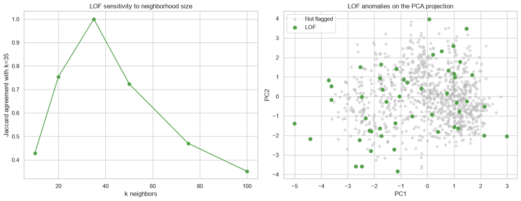

```python
lof_sensitivity_rows = []
lof_outputs = {}
for neighbors in [10, 20, 35, 50, 75, 100]:
    start = perf_counter()
    detector = LocalOutlierFactor(n_neighbors=neighbors, contamination=.05)
    labels = detector.fit_predict(X_scaled)
    elapsed = perf_counter() - start
    lof_outputs[neighbors] = {
        "flags": labels == -1,
        "scores": -detector.negative_outlier_factor_,
        "runtime": elapsed,
    }

LOF_K = 35
lof_flags = lof_outputs[LOF_K]["flags"]
lof_scores = lof_outputs[LOF_K]["scores"]
runtime_seconds["LOF"] = lof_outputs[LOF_K]["runtime"]
for neighbors, result in lof_outputs.items():
    comparison = result["flags"]
    lof_sensitivity_rows.append(
        {
            "neighbors": neighbors,
            "flagged": int(comparison.sum()),
            "Jaccard vs k=35": (comparison & lof_flags).sum() / (comparison | lof_flags).sum(),
            "runtime_seconds": result["runtime"],
        }
    )
lof_sensitivity = pd.DataFrame(lof_sensitivity_rows)
display(lof_sensitivity)

fig, axes = plt.subplots(1, 2, figsize=(14, 5.5))
axes[0].plot(lof_sensitivity["neighbors"], lof_sensitivity["Jaccard vs k=35"], marker="o", color="#54A24B")
axes[0].set_title("LOF sensitivity to neighborhood size")
axes[0].set_xlabel("k neighbors")
axes[0].set_ylabel("Jaccard agreement with k=35")
axes[1].scatter(projection["PC1"], projection["PC2"], c="#B8B8B8", s=20, alpha=.45, label="Not flagged")
axes[1].scatter(projection.loc[lof_flags, "PC1"], projection.loc[lof_flags, "PC2"], c="#54A24B", s=42, label="LOF")
axes[1].set_title("LOF anomalies on the PCA projection")
axes[1].set_xlabel("PC1")
axes[1].set_ylabel("PC2")
axes[1].legend()
fig.tight_layout()
save_figure("15_lof_sensitivity_and_anomalies.png")
plt.show()
```

## 6. Comparison of anomaly detectors

The classical Z-score threshold produces its own data-dependent count. For direct method overlap, all three rankings are also compared at a common 5% review budget (50 models). This separates the question "what does the textbook threshold flag?" from "which 50 cases would each method prioritize?"

|  | Z-score | Isolation Forest | LOF |
| --- | --- | --- | --- |
| Z-score | 1.000 | 0.176 | 0.190 |
| Isolation Forest | 0.176 | 1.000 | 0.351 |
| LOF | 0.190 | 0.351 | 1.000 |

|  | Z-score | Isolation Forest | LOF | models |
| --- | --- | --- | --- | --- |
| 0 | 0 | 0 | 0 | 895 |
| 1 | 1 | 0 | 0 | 31 |
| 2 | 0 | 1 | 0 | 21 |
| 3 | 0 | 0 | 1 | 20 |
| 4 | 0 | 1 | 1 | 14 |
| 5 | 1 | 1 | 1 | 12 |
| 6 | 1 | 0 | 1 | 4 |
| 7 | 1 | 1 | 0 | 3 |

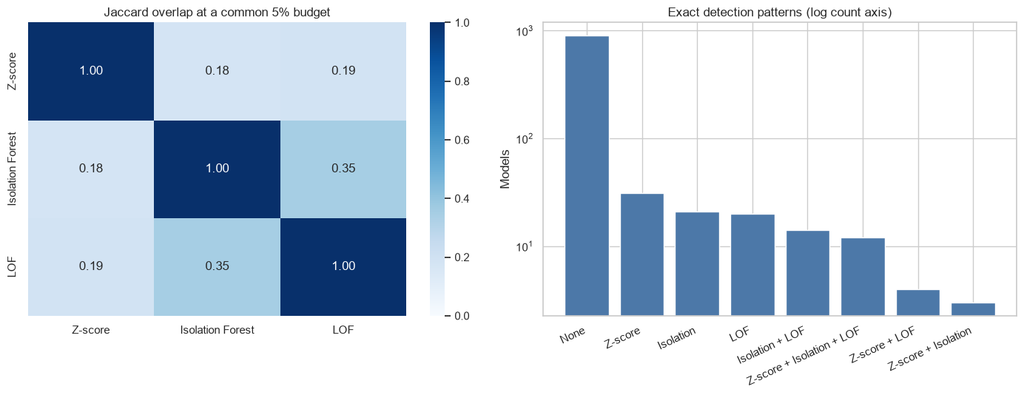

```python
anomaly_flags = pd.DataFrame(
    {
        "Z-score": z_equal_budget_flags,
        "Isolation Forest": isolation_flags,
        "LOF": lof_flags,
    },
    index=models.index,
)

jaccard = pd.DataFrame(index=anomaly_flags.columns, columns=anomaly_flags.columns, dtype=float)
for left in anomaly_flags:
    for right in anomaly_flags:
        union = (anomaly_flags[left] | anomaly_flags[right]).sum()
        jaccard.loc[left, right] = (anomaly_flags[left] & anomaly_flags[right]).sum() / union
display(jaccard)

pattern_counts = (
    anomaly_flags.astype(int)
    .value_counts()
    .rename("models")
    .reset_index()
    .sort_values("models", ascending=False)
)
display(pattern_counts)

fig, axes = plt.subplots(1, 2, figsize=(14, 5.5))
sns.heatmap(jaccard, annot=True, fmt=".2f", vmin=0, vmax=1, cmap="Blues", ax=axes[0])
axes[0].set_title("Jaccard overlap at a common 5% budget")
def pattern_label(row: pd.Series) -> str:
    selected = [
        name
        for name, active in [
            ("Z-score", row["Z-score"]),
            ("Isolation", row["Isolation Forest"]),
            ("LOF", row["LOF"]),
        ]
        if active
    ]
    return "None" if not selected else " + ".join(selected)


pattern_labels = pattern_counts.apply(pattern_label, axis=1)
axes[1].bar(pattern_labels, pattern_counts["models"], color="#4C78A8")
axes[1].set_yscale("log")
axes[1].set_title("Exact detection patterns (log count axis)")
axes[1].set_xlabel("")
axes[1].set_ylabel("Models")
axes[1].tick_params(axis="x", rotation=25)
for label in axes[1].get_xticklabels():
    label.set_horizontalalignment("right")
fig.tight_layout()
save_figure("16_anomaly_method_overlap.png")
plt.show()
```

```python
anomaly_results = models[
    ["id", "author", "pipeline_tag", "downloads", "likes", "model_age_days", "days_since_update", "tag_count", "gated_flag"]
].copy()
anomaly_results["z_score"] = z_scores
anomaly_results["z_classical_flag"] = z_classical_flags
anomaly_results["z_equal_budget_flag"] = z_equal_budget_flags
anomaly_results["z_most_extreme_feature"] = z_contributor
anomaly_results["isolation_score"] = isolation_scores
anomaly_results["isolation_flag"] = isolation_flags
anomaly_results["lof_score"] = lof_scores
anomaly_results["lof_flag"] = lof_flags
anomaly_results["agreement_count"] = anomaly_flags.sum(axis=1).to_numpy()
anomaly_results = anomaly_results.sort_values(
    ["agreement_count", "isolation_score", "lof_score"], ascending=False
)
anomaly_results.to_csv(ROOT / "reports" / "anomaly_results.csv", index=False, lineterminator="\n")
display(anomaly_results.head(20))

all_three = anomaly_results.query("agreement_count == 3")
print(f"Flagged by all three equal-budget methods: {len(all_three)}")
print(f"Flagged by at least one equal-budget method: {(anomaly_flags.sum(axis=1) > 0).sum()}")
```

|  | id | author | pipeline_tag | downloads | likes | model_age_days | days_since_update | tag_count | gated_flag | z_score | z_classical_flag | z_equal_budget_flag | z_most_extreme_feature | isolation_score | isolation_flag | lof_score | lof_flag | agreement_count |
| --- | --- | --- | --- | --- | --- | --- | --- | --- | --- | --- | --- | --- | --- | --- | --- | --- | --- | --- |
| 155450 | DavidAU/Qwen3.6-27B-Fable-Fusion-711-Uncensore... | DavidAU | image-text-to-text | 955767 | 1011 | 12.981 | 0.678 | 37 | 0 | 4.788 | True | True | model_id_length | 0.657 | True | 1.962 | True | 3 |
| 155508 | k2-fsa/OmniVoice | k2-fsa | text-to-speech | 859784 | 1222 | 121.428 | 26.853 | 657 | 0 | 6.133 | True | True | log_tag_count | 0.633 | True | 1.747 | True | 3 |
| 155256 | farbodtavakkoli/OTel-2.0-LLM-31B-IT | farbodtavakkoli | text-generation | 1797286 | 4 | 6.522 | 0.000 | 26 | 0 | 3.847 | True | True | log_model_age_days | 0.610 | True | 1.544 | True | 3 |
| 155004 | sentence-transformers/paraphrase-multilingual-... | sentence-transformers | sentence-similarity | 55559128 | 1337 | 1,610.021 | 182.582 | 67 | 0 | 4.017 | True | True | log_downloads | 0.599 | True | 1.507 | True | 3 |
| 155924 | nvidia/Qwen3-VL-235B-A22B-Instruct-NVFP4-MLPer... | nvidia | unknown | 413713 | 3 | 44.229 | 42.212 | 5 | 0 | 4.491 | True | True | model_id_length | 0.599 | True | 1.552 | True | 3 |
| 155939 | yuxinlu1/gemma-4-12B-agentic-fable5-composer2.... | yuxinlu1 | text-generation | 400218 | 1338 | 40.996 | 40.603 | 17 | 0 | 3.401 | True | True | model_id_length | 0.599 | True | 1.444 | True | 3 |
| 155000 | sentence-transformers/all-MiniLM-L6-v2 | sentence-transformers | sentence-similarity | 254507269 | 5144 | 1,610.021 | 58.730 | 47 | 0 | 5.583 | True | True | log_downloads | 0.589 | True | 1.604 | True | 3 |
| 155167 | baidu/Unlimited-OCR | baidu | image-text-to-text | 2598659 | 3574 | 40.597 | 0.810 | 14 | 0 | 3.412 | True | True | log_days_since_update | 0.575 | True | 1.331 | True | 3 |
| 155810 | handy-computer/whisper-medium-gguf | handy-computer | automatic-speech-recognition | 484747 | 0 | 93.909 | 31.444 | 111 | 0 | 3.248 | True | True | log_tag_count | 0.575 | True | 1.439 | True | 3 |
| 155967 | bosonai/higgs-tts-3-4b | bosonai | text-to-speech | 383830 | 683 | 55.766 | 20.232 | 113 | 0 | 3.277 | True | True | log_tag_count | 0.574 | True | 1.504 | True | 3 |
| 155009 | lpiccinelli/unidepth-v2-vitl14 | lpiccinelli | unknown | 27002738 | 47 | 777.473 | 516.420 | 7 | 0 | 3.275 | True | True | log_downloads | 0.560 | True | 1.322 | True | 3 |
| 155973 | DeepBeepMeep/Wan2.1 | DeepBeepMeep | unknown | 380932 | 45 | 516.598 | 0.286 | 8 | 0 | 3.647 | True | True | log_days_since_update | 0.556 | True | 1.398 | True | 3 |
| 155043 | coqui/XTTS-v2 | coqui | text-to-speech | 9187102 | 3698 | 1,002.575 | 961.257 | 4 | 0 | 2.726 | False | False | log_library_model_count | 0.626 | True | 1.374 | True | 2 |
| 155472 | phanviethoang1512/qwen3.5-4b-base-osim-253991 | phanviethoang1512 | unknown | 920964 | 0 | 21.223 | 20.078 | 3 | 0 | 2.852 | False | False | log_model_age_days | 0.600 | True | 1.317 | True | 2 |
| 155226 | handy-computer/nemotron-3.5-asr-streaming-0.6b... | handy-computer | automatic-speech-recognition | 1960108 | 2 | 52.967 | 30.764 | 45 | 0 | 2.037 | False | False | log_model_age_days | 0.582 | True | 1.370 | True | 2 |
| 155942 | nvidia/Nemotron-3-Embed-1B-BF16 | nvidia | sentence-similarity | 399655 | 123 | 15.686 | 9.094 | 54 | 0 | 3.115 | True | False | log_model_age_days | 0.580 | True | 1.387 | True | 2 |
| 155430 | openbmb/VoxCPM2 | openbmb | text-to-speech | 1019206 | 1503 | 117.774 | 104.854 | 42 | 0 | 2.726 | False | False | log_library_model_count | 0.580 | True | 1.293 | True | 2 |
| 155073 | NN-Dataset/tflite | NN-Dataset | unknown | 5676622 | 1 | 170.315 | 34.743 | 2 | 0 | 2.649 | False | False | log_tag_count | 0.579 | True | 1.508 | True | 2 |
| 155853 | 1-800-BAD-CODE/xlm-roberta_punctuation_fullsto... | 1-800-BAD-CODE | unknown | 451748 | 67 | 1,179.060 | 1,110.137 | 57 | 0 | 2.508 | False | False | model_id_length | 0.576 | True | 1.433 | True | 2 |
| 155890 | SulphurAI/Sulphur-2-base | SulphurAI | text-to-video | 428061 | 1939 | 87.977 | 35.248 | 9 | 0 | 3.121 | True | False | log_pipeline_model_count | 0.576 | True | 1.304 | True | 2 |

```
Flagged by all three equal-budget methods: 12
Flagged by at least one equal-budget method: 105
```

|  | method | scaling_jaccard | PCA90_jaccard | mean_jaccard | minimum_jaccard | runtime_seconds |
| --- | --- | --- | --- | --- | --- | --- |
| 0 | Z-score | 1.000 | 0.235 | 0.901 | 0.852 | 0.002 |
| 1 | Isolation Forest | 1.000 | 0.471 | 0.810 | 0.754 | 0.408 |
| 2 | LOF | 0.282 | 0.587 | 0.931 | 0.887 | 0.017 |

|  | method | ARI: primary 9 vs all 13 | all-13 silhouette | all-13 noise fraction |
| --- | --- | --- | --- | --- |
| 0 | K-Means | 0.313 | 0.165 | 0.000 |
| 1 | DBSCAN | 0.154 | 0.239 | 0.122 |
| 2 | Agglomerative | 0.038 | 0.147 | 0.000 |

|  | method | Jaccard: primary 9 vs all 13 |
| --- | --- | --- |
| 0 | Isolation Forest | 0.220 |
| 1 | LOF | 0.408 |

|  | indicator | models | prevalence | Z-score flag rate | Isolation Forest flag rate | LOF flag rate |
| --- | --- | --- | --- | --- | --- | --- |
| 0 | gated_flag | 44 | 0.044 | 0.000 | 0.000 | 0.000 |
| 1 | library_missing | 79 | 0.079 | 0.025 | 0.114 | 0.101 |
| 2 | has_license_tag | 885 | 0.885 | 0.050 | 0.044 | 0.043 |
| 3 | has_arxiv_reference | 584 | 0.584 | 0.057 | 0.041 | 0.046 |

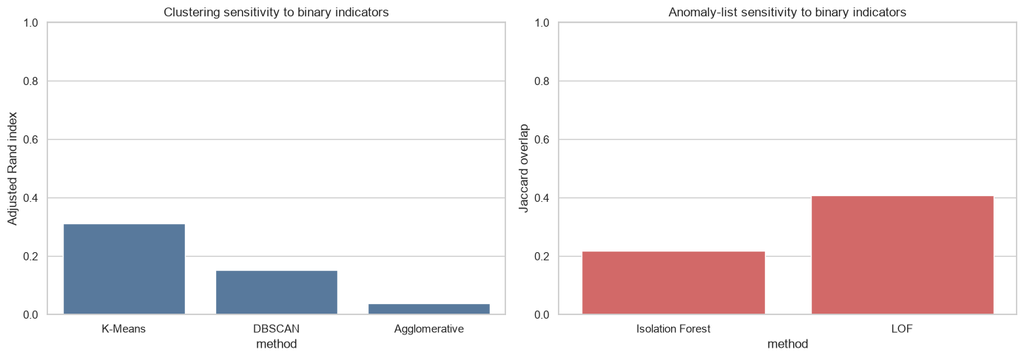

```python
def jaccard_score_flags(left: np.ndarray, right: np.ndarray) -> float:
    left = np.asarray(left, dtype=bool)
    right = np.asarray(right, dtype=bool)
    return float((left & right).sum() / (left | right).sum())


# Scaling sensitivity: the same nine transformed continuous features, before and after StandardScaler.
X_unscaled = X.to_numpy(float)
z_unscaled_flags = top_n_flags(np.abs(StandardScaler().fit_transform(X[continuous_features])).max(axis=1))
if_unscaled_model = IsolationForest(n_estimators=400, contamination="auto", random_state=SEED, n_jobs=-1).fit(X_unscaled)
if_unscaled_flags = top_n_flags(-if_unscaled_model.score_samples(X_unscaled))
lof_unscaled_model = LocalOutlierFactor(n_neighbors=LOF_K).fit(X_unscaled)
lof_unscaled_flags = top_n_flags(-lof_unscaled_model.negative_outlier_factor_)

# Dimensionality sensitivity: refit in the PCA space retaining at least 90% variance.
pca90_components = components_needed[.90]
X_pca90 = pca_scores[:, :pca90_components]
z_pca90_flags = top_n_flags(np.abs(StandardScaler().fit_transform(X_pca90)).max(axis=1))
if_pca90_model = IsolationForest(n_estimators=400, contamination="auto", random_state=SEED, n_jobs=-1).fit(X_pca90)
if_pca90_flags = top_n_flags(-if_pca90_model.score_samples(X_pca90))
lof_pca90_model = LocalOutlierFactor(n_neighbors=LOF_K).fit(X_pca90)
lof_pca90_flags = top_n_flags(-lof_pca90_model.negative_outlier_factor_)

# Robustness to small measurement noise: mean Jaccard over ten 3% Gaussian perturbations.
noise_rows = []
for method, baseline in [
    ("Z-score", z_equal_budget_flags),
    ("Isolation Forest", isolation_flags),
    ("LOF", lof_flags),
]:
    agreements = []
    for trial in range(10):
        jittered = X_scaled + np.random.default_rng(SEED + trial).normal(0, .03, X_scaled.shape)
        if method == "Z-score":
            alternative = top_n_flags(np.abs(jittered[:, : len(continuous_features)]).max(axis=1))
        elif method == "Isolation Forest":
            fitted = IsolationForest(n_estimators=400, contamination="auto", random_state=SEED + trial, n_jobs=-1).fit(jittered)
            alternative = top_n_flags(-fitted.score_samples(jittered))
        else:
            fitted = LocalOutlierFactor(n_neighbors=LOF_K).fit(jittered)
            alternative = top_n_flags(-fitted.negative_outlier_factor_)
        agreements.append(jaccard_score_flags(baseline, alternative))
    noise_rows.append({"method": method, "mean_jaccard": np.mean(agreements), "minimum_jaccard": np.min(agreements)})

sensitivity = pd.DataFrame(
    [
        {"method": "Z-score", "scaling_jaccard": jaccard_score_flags(z_equal_budget_flags, z_unscaled_flags), "PCA90_jaccard": jaccard_score_flags(z_equal_budget_flags, z_pca90_flags)},
        {"method": "Isolation Forest", "scaling_jaccard": jaccard_score_flags(isolation_flags, if_unscaled_flags), "PCA90_jaccard": jaccard_score_flags(isolation_flags, if_pca90_flags)},
        {"method": "LOF", "scaling_jaccard": jaccard_score_flags(lof_flags, lof_unscaled_flags), "PCA90_jaccard": jaccard_score_flags(lof_flags, lof_pca90_flags)},
    ]
).merge(pd.DataFrame(noise_rows), on="method")
sensitivity["runtime_seconds"] = sensitivity["method"].map(runtime_seconds)
display(sensitivity)

# Feature-set sensitivity: repeat the main methods after adding the four binary indicators.
all_scaler = StandardScaler()
X_all_scaled = all_scaler.fit_transform(X_all)
all_neighbor_distances = NearestNeighbors(n_neighbors=DBSCAN_MIN_SAMPLES).fit(X_all_scaled).kneighbors(X_all_scaled)[0][:, -1]
all_dbscan_eps = float(np.quantile(all_neighbor_distances, DBSCAN_QUANTILE))
all_feature_cluster_labels = {
    "K-Means": KMeans(n_clusters=KMEANS_K, n_init=30, random_state=SEED).fit_predict(X_all_scaled),
    "DBSCAN": DBSCAN(eps=all_dbscan_eps, min_samples=DBSCAN_MIN_SAMPLES).fit_predict(X_all_scaled),
    "Agglomerative": AgglomerativeClustering(n_clusters=AGGLOMERATIVE_K, linkage="ward").fit_predict(X_all_scaled),
}
cluster_feature_set_sensitivity = pd.DataFrame(
    [
        {
            "method": method,
            "ARI: primary 9 vs all 13": adjusted_rand_score(cluster_labels[method], labels),
            "all-13 silhouette": clustering_metrics(X_all_scaled, labels)["silhouette"],
            "all-13 noise fraction": clustering_metrics(X_all_scaled, labels)["noise_fraction"],
        }
        for method, labels in all_feature_cluster_labels.items()
    ]
)

all_feature_if = IsolationForest(
    n_estimators=400, contamination="auto", random_state=SEED, n_jobs=-1
).fit(X_all_scaled)
all_feature_if_flags = top_n_flags(-all_feature_if.score_samples(X_all_scaled))
all_feature_lof = LocalOutlierFactor(n_neighbors=LOF_K).fit(X_all_scaled)
all_feature_lof_flags = top_n_flags(-all_feature_lof.negative_outlier_factor_)
anomaly_feature_set_sensitivity = pd.DataFrame(
    {
        "method": ["Isolation Forest", "LOF"],
        "Jaccard: primary 9 vs all 13": [
            jaccard_score_flags(isolation_flags, all_feature_if_flags),
            jaccard_score_flags(lof_flags, all_feature_lof_flags),
        ],
    }
)
cluster_feature_set_sensitivity.to_csv(ROOT / "reports" / "clustering_feature_set_sensitivity.csv", index=False, lineterminator="\n")
anomaly_feature_set_sensitivity.to_csv(ROOT / "reports" / "anomaly_feature_set_sensitivity.csv", index=False, lineterminator="\n")
display(cluster_feature_set_sensitivity)
display(anomaly_feature_set_sensitivity)

subgroup_rows = []
for indicator in binary_features:
    group = models[indicator].astype(bool).to_numpy()
    subgroup_rows.append(
        {
            "indicator": indicator,
            "models": int(group.sum()),
            "prevalence": group.mean(),
            "Z-score flag rate": z_equal_budget_flags[group].mean() if group.any() else np.nan,
            "Isolation Forest flag rate": isolation_flags[group].mean() if group.any() else np.nan,
            "LOF flag rate": lof_flags[group].mean() if group.any() else np.nan,
        }
    )
binary_indicator_profiles = pd.DataFrame(subgroup_rows)
binary_indicator_profiles.to_csv(ROOT / "reports" / "binary_indicator_profiles.csv", index=False, lineterminator="\n")
display(binary_indicator_profiles)

fig, axes = plt.subplots(1, 2, figsize=(14, 5))
sns.barplot(
    data=cluster_feature_set_sensitivity,
    x="method",
    y="ARI: primary 9 vs all 13",
    color="#4C78A8",
    ax=axes[0],
)
axes[0].set_ylim(0, 1)
axes[0].set_title("Clustering sensitivity to binary indicators")
axes[0].set_ylabel("Adjusted Rand index")
sns.barplot(
    data=anomaly_feature_set_sensitivity,
    x="method",
    y="Jaccard: primary 9 vs all 13",
    color="#E45756",
    ax=axes[1],
)
axes[1].set_ylim(0, 1)
axes[1].set_title("Anomaly-list sensitivity to binary indicators")
axes[1].set_ylabel("Jaccard overlap")
fig.tight_layout()
save_figure("17_feature_set_sensitivity.png")
plt.show()
```

### 6.1 Agreement and method-specific anomalies

At the common 5% budget, 12 models are selected by all three methods, and 105 are selected by at least one. Pairwise Jaccard agreement remains limited: 0.176 for Z-score/Isolation Forest, 0.190 for Z-score/LOF, and 0.351 for Isolation Forest/LOF. The detectors are not interchangeable.

- Z-score prioritizes a single extreme continuous coordinate, such as very high downloads or tag count.
- Isolation Forest finds combinations that require unusually short random partition paths, even when no coordinate exceeds three standard deviations.
- LOF finds points whose density is low relative to their particular neighborhood. Its selected set changes sharply with $k$, confirming strong neighborhood sensitivity.

`k2-fsa/OmniVoice` is a useful ambiguous example. All three methods flag it, largely because its tag count is 657 while its downloads and age are not comparably extreme. That can be a legitimate, heavily annotated speech repository rather than a data error. `sentence-transformers/all-MiniLM-L6-v2` is another legitimate but unusual case: extremely high infrastructure use makes it globally exceptional even though nothing is inherently wrong with the repository.

### 6.2 Scaling, dimensionality, runtime, and noise

The sensitivity table reports empirical Jaccard overlap rather than relying only on theory. Z-score is affine-scale invariant because it standardizes internally. Isolation Forest is nearly invariant to independent positive rescaling of each feature because axis-aligned split order is preserved. LOF is strongly scale-sensitive because raw large-range coordinates dominate Euclidean neighborhoods.

Using only the seven PCA components needed for 90% variance changes all three review lists. Variance preservation is not anomaly preservation: low-variance directions can contain rare behavior. This is why the anomaly plots in 2D may hide points detected in nine dimensions or make projected edge points look suspicious when their full-space neighborhood is ordinary.

On 1,000 rows, all runtimes are small. The theoretical difference matters at scale: Z-score is $O(nd)$; Isolation Forest is approximately $O(t\,\psi\log\psi)$ for $t$ trees and subsample size $\psi$; exact LOF neighbor search can approach $O(n^2d)$ when tree-based neighbor search deteriorates in high dimensions. Under small Gaussian perturbations, Z-score and LOF rankings are stable here, while Isolation Forest varies more because both the data and randomized partitions change.

The Isolation Forest contamination sweep makes the threshold choice visible: contamination values of 1%, 2.5%, 5%, 7.5%, and 10% flag exactly 10, 25, 50, 75, and 100 rows. Relative to the 5% list, Jaccard overlap is 0.20, 0.50, 1.00, 0.67, and 0.50. Contamination therefore controls review volume; it is not evidence for the true anomaly rate.

### 6.3 Feature-set sensitivity and binary subgroup audit

Adding the four binary indicators changes the geometry substantially even after retuning DBSCAN by the same neighbor-quantile rule. Agreement between the primary-nine and all-13 clusterings is low: ARI is 0.313 for K-Means, 0.154 for DBSCAN, and 0.038 for Ward. The all-13 DBSCAN solution has an assigned-point silhouette of 0.239 and 12.2% noise, but it answers a different question in which rare access/metadata states help define density. The top-5% anomaly lists also shift: Jaccard overlap is 0.220 for Isolation Forest and 0.408 for LOF. These empirical results support using the nine continuous features for the main comparison rather than allowing rare access/metadata states to manufacture distance.

The binary indicators are not discarded. Their prevalence and method-specific flag rates are reported separately in `binary_indicator_profiles.csv`. This makes possible disparities visible without treating gated access, a missing library value, licensing metadata, or an arXiv reference as inherently abnormal.

### 6.4 Interpretability and robustness

Z-score is easiest to explain and names the extreme feature, but Gaussian tail language is unreliable for the skewed distributions. Isolation Forest captures interactions and scales well, but its score is less tied to one business reason. LOF has an intuitive local-density interpretation, but a result is inseparable from its neighborhood definition. No method is robust to arbitrary noise, missing variables, or a badly chosen representation.

### 6.5 False positives and false negatives without labels

There is no confirmed normal/anomalous label, so a numeric confusion matrix would be invented. In this context, a **false positive** would send a legitimate repository for unnecessary review; repeated false alarms would waste analyst time and cause alert fatigue. A **false negative** would miss corrupted metadata, manipulation, a sudden popularity event, or another genuinely important change. Which error is worse depends on the intended use. A low-cost metadata audit may favor recall; suspending model access would require much higher precision and human verification.

## 7. Critical analysis and reflection

### Why anomaly detection is ill-defined

Anomaly detection has no universal target. Rare, surprising, harmful, erroneous, and novel are different concepts. A blockbuster model, a gated model, and a malformed row can all be statistically unusual for different reasons. Contamination and thresholds encode operational choices, not natural laws. Without reviewed examples, agreement supports prioritization but does not prove correctness.

### Curse of dimensionality

As dimension grows, data occupy an exponentially larger space. Samples become sparse, local neighborhoods contain fewer genuinely comparable points, and nearest and farthest distances can become similar relative to their scale. This concentration weakens the meaning of Euclidean distance for LOF and DBSCAN. Irrelevant features also add noise to every distance. Standardization fixes units, not sparsity or relevance.

### Noise versus a genuine anomaly

Noise is an unreliable measurement or random fluctuation; a genuine anomaly is a valid observation that matters for the question. `k2-fsa/OmniVoice` may be genuine because an unusually large tag list can reflect broad compatibility or automated metadata. A broken parser that duplicated tags would instead be noise. The numbers alone cannot decide; the repository card and collection pipeline would need verification.

### Risks of Gaussian assumptions

Downloads and tag counts retain positive skew and excess kurtosis after logs, while the binary fields are not Gaussian at all. A fixed Z threshold may over-flag legitimate heavy-tail observations, and mean/standard deviation can themselves be distorted by extremes. Conversely, a point that is moderate in every marginal feature but has an impossible combination can be missed. Correlation also means feature-wise tests are not independent.

### Why PCA pictures can mislead

The 2D plane retains only 42.6% of standardized variance. Distant full-space points can overlap after projection, and apparently separated points can differ mainly along two high-variance directions while being ordinary in the remaining dimensions. PCA preserves global variance, not local density, cluster membership, or anomaly scores. Every PCA anomaly/cluster plot in this notebook is therefore a display of nine-dimensional decisions, not the space used to make those decisions.

### Methodological limitations

- The latest snapshot removes repeated-row dependence but discards growth trajectories.
- The source includes trending models, so the sample is selected toward visibility and is not representative of the full Hub.
- Download counts are rolling 30-day activity, not unique users or value created.
- Likes, tags, and model cards are influenced by publisher behavior and community norms.
- Feature engineering embeds choices about what counts as ecosystem prominence or metadata richness.
- Rare binary features can dominate standardized distances; the primary/supplementary split and the explicit all-feature sensitivity test quantify that risk.
- The analysis validates internal geometry and stability, not external truth.

A stronger follow-up would combine time-series growth features, authoritative model-card checks for flagged rows, mixed-type distances, robust covariance baselines, and expert-reviewed anomaly labels.

### Ethical considerations

**False alarms:** If every unusual model triggers escalation, reviewers learn to ignore the system. High-impact actions should never be based on an unsupervised score alone.

**Surveillance:** Anomaly detection can surface abuse or compromised accounts, but broad behavioral monitoring can invade privacy and chill legitimate experimentation. Purpose limitation, minimum data collection, access controls, and appeal mechanisms are essential.

**Medicine:** A false positive can cause anxiety, unnecessary tests, and cost; a false negative can delay treatment. Clinical systems require validated labels, subgroup performance checks, and clinician oversight. This notebook's exploratory workflow would not be sufficient.

**Cybersecurity:** Missing a real attack can expose systems and data, while flagging legitimate activity can block work and overwhelm responders. Thresholds should reflect asset criticality, and alerts need contextual evidence.

**Bias and fairness:** Underrepresented publishers, languages, tasks, or licensing practices may look anomalous simply because the dataset contains fewer of them. Labeling a repository, person, or behavior as "abnormal" can stigmatize difference and amplify historical sampling bias. Scores should be framed as review priorities, documented, audited across subgroups, and contestable.

## 8. Visualization dashboard (bonus)

The interactive PCA view below supports hover-based inspection by model ID, task, downloads, and the three anomaly decisions. It is also written to `reports/anomaly_dashboard.html` as a self-contained file. The pairplot and signature heatmap provide complementary distribution and feature-level views.

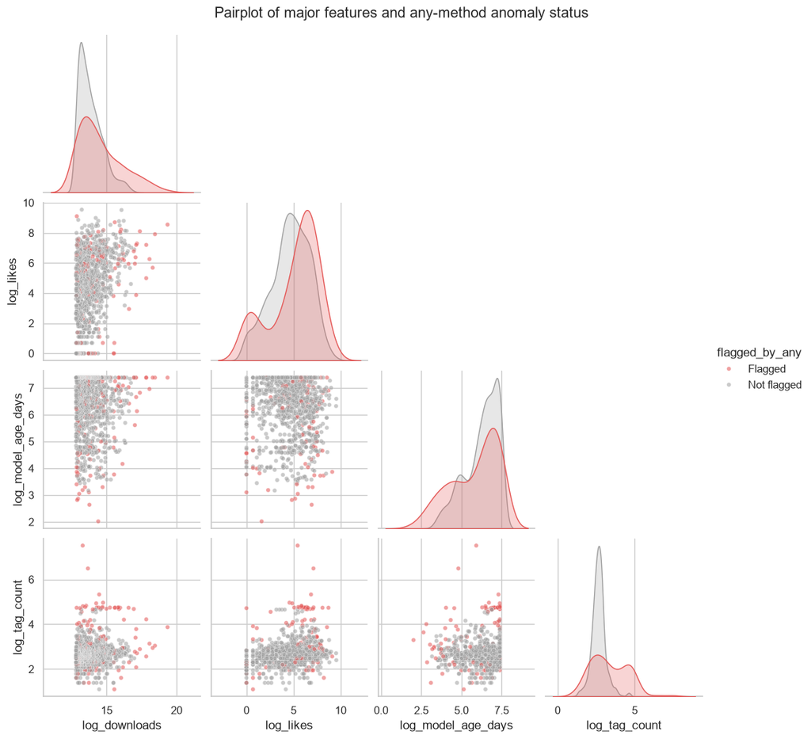

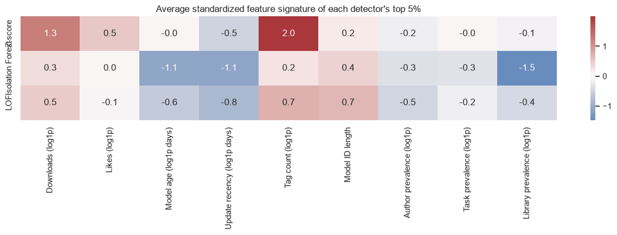

```python
dashboard = models[["id", "author", "pipeline_tag", "downloads", "likes"]].copy()
dashboard[["PC1", "PC2", "PC3"]] = pca_scores[:, :3]
dashboard["Z-score"] = z_equal_budget_flags
dashboard["Isolation Forest"] = isolation_flags
dashboard["LOF"] = lof_flags
dashboard["agreement_count"] = anomaly_flags.sum(axis=1).to_numpy()
dashboard["status"] = dashboard["agreement_count"].map(
    {0: "Not flagged", 1: "One method", 2: "Two methods", 3: "All three methods"}
)

interactive_figure = px.scatter(
    dashboard,
    x="PC1",
    y="PC2",
    color="status",
    size="agreement_count",
    size_max=14,
    hover_name="id",
    hover_data=["author", "pipeline_tag", "downloads", "likes", "Z-score", "Isolation Forest", "LOF"],
    category_orders={"status": ["Not flagged", "One method", "Two methods", "All three methods"]},
    color_discrete_map={
        "Not flagged": "#B8B8B8",
        "One method": "#4C78A8",
        "Two methods": "#F58518",
        "All three methods": "#E45756",
    },
    title="Interactive anomaly exploration on the PCA projection",
)
interactive_figure.update_traces(marker={"opacity": .75})
interactive_figure.write_html(
    ROOT / "reports" / "anomaly_dashboard.html",
    include_plotlyjs=True,
    full_html=True,
)
interactive_figure.show()

pairplot_frame = models[["log_downloads", "log_likes", "log_model_age_days", "log_tag_count"]].copy()
pairplot_frame["flagged_by_any"] = np.where(anomaly_flags.any(axis=1), "Flagged", "Not flagged")
pair_grid = sns.pairplot(
    pairplot_frame,
    hue="flagged_by_any",
    corner=True,
    plot_kws={"s": 18, "alpha": .55},
    diag_kws={"common_norm": False},
    palette={"Not flagged": "#A0A0A0", "Flagged": "#E45756"},
)
pair_grid.fig.suptitle("Pairplot of major features and any-method anomaly status", y=1.02)
pair_grid.savefig(FIGURE_DIR / "18_anomaly_pairplot.png", dpi=180, bbox_inches="tight")
plt.show()

signature_rows = []
for method, flags in anomaly_flags.items():
    signature_rows.append(pd.Series(X_scaled[flags].mean(axis=0), index=feature_columns, name=method))
signature = pd.DataFrame(signature_rows)
fig, ax = plt.subplots(figsize=(13, 4.5))
sns.heatmap(signature.rename(columns=feature_labels), cmap="vlag", center=0, annot=True, fmt=".1f", ax=ax)
ax.set_title("Average standardized feature signature of each detector's top 5%")
ax.set_xlabel("")
fig.tight_layout()
save_figure("19_anomaly_signature_heatmap.png")
plt.show()
```

## 9. Conclusions

1. The latest-snapshot data do not contain strongly separated natural clusters. Five K-Means personas, two Ward branches, and two DBSCAN density regions summarize different aspects of a mostly continuous, overlapping space.
2. Age and update recency are genuinely redundant, but PCA still needs seven components to retain 90% of the nine-feature primary variance. Two-dimensional views are lossy.
3. Feature clustering confirms a lifecycle pair and an ecosystem-prevalence pair, while most other relationships are weak.
4. The classical Z-score flags 70 rows at $|z|>3$. At a matched 5% budget, the three anomaly methods agree on 12 models, demonstrating that "anomaly" depends on global extremes, random isolation, or local density.
5. Feature-set and contamination sweeps show that representation and review budget materially change the result. The most defensible output is a prioritized review list with method reasons, not a declaration that 50 models are bad. Real-world verification is required before any action.

### References

1. [Kaggle - Hugging Face Models Trending](https://www.kaggle.com/datasets/zoupet/hugging-face-models-trending)
2. [Hugging Face Hub API - `ModelInfo`](https://huggingface.co/docs/huggingface_hub/package_reference/hf_api)
3. [Hugging Face - Gated models](https://huggingface.co/docs/hub/models-gated)
4. Liu, Ting, and Zhou (2008), [Isolation Forest](https://doi.org/10.1109/ICDM.2008.17)
5. Breunig et al. (2000), [LOF: Identifying Density-Based Local Outliers](https://doi.org/10.1145/335191.335388)

```python
# Final reproducibility and completeness checks.
required_figures = [FIGURE_DIR / f"{number:02d}_{name}" for number, name in [
    (1, "feature_histograms.png"),
    (2, "feature_boxplots.png"),
    (3, "binary_feature_counts.png"),
    (4, "correlation_matrix.png"),
    (5, "pca_scree_and_cumulative.png"),
    (6, "pca_loadings.png"),
    (7, "pca_2d_3d.png"),
    (8, "clustering_parameter_selection.png"),
    (9, "dbscan_parameter_selection.png"),
    (10, "cluster_pca_comparison.png"),
    (11, "kmeans_cluster_profiles.png"),
    (12, "feature_clustering.png"),
    (13, "zscore_anomalies.png"),
    (14, "isolation_forest_anomalies.png"),
    (15, "lof_sensitivity_and_anomalies.png"),
    (16, "anomaly_method_overlap.png"),
    (17, "feature_set_sensitivity.png"),
    (18, "anomaly_pairplot.png"),
    (19, "anomaly_signature_heatmap.png"),
]]
assert all(path.exists() and path.stat().st_size > 0 for path in required_figures)
assert (ROOT / "reports" / "anomaly_dashboard.html").stat().st_size > 0
assert (ROOT / "reports" / "anomaly_results.csv").stat().st_size > 0
assert (ROOT / "reports" / "clustering_results.csv").stat().st_size > 0
assert (ROOT / "reports" / "feature_dictionary.csv").stat().st_size > 0
assert (ROOT / "reports" / "binary_indicator_profiles.csv").stat().st_size > 0
assert (ROOT / "reports" / "if_contamination_sensitivity.csv").stat().st_size > 0
assert (ROOT / "data" / "processed" / "hf_models_latest_numeric.csv").stat().st_size > 0
assert len(feature_columns) >= 8 and len(models) >= 1_000
assert len(all_numeric_features) == 13 and numeric_share > .50
assert anomaly_flags.sum().eq(anomaly_budget).all()
assert len(all_three) == 12
assert components_needed[.90] == 7

print("All analytical, figure, export, and reproducibility checks passed.")
print(f"Figures verified: {len(required_figures)}")
print(f"Notebook rows: {len(models):,}; primary features: {len(feature_columns)}; processed numerical features: {len(all_numeric_features)}")
```

```
All analytical, figure, export, and reproducibility checks passed.
Figures verified: 19
Notebook rows: 1,000; primary features: 9; processed numerical features: 13
```